# 短期光伏功率预测

数据描述

李家翔 https://jiaxiangli.netlify.com  
2018-11-05

### Table of Contents

# 总结

目前模型主要实现是在Xgboost上。总结下来是四个阶段。

1. `reg:linear`，超参数我是按照自己的sense附上的，排名是65
2. `reg:linear`，超参数是grid后选择的，排名是64
3. `reg:tweedie`，超参数我是按照自己的sense附上的，排名是46
4. `reg:tweedie`，超参数是grid后选择的，排名是39

**提升的方向。**

因此我认为在当前数据质量下，我觉得这两方面，对优化比较重要。

1. 替换**训练目标**，使得目标更加符合y分布。
2. 选择了训练目标后，通过优超参数。
   1. 但是显然这个的优化效果是不稳定的，可以看以上`reg:linear`的超参数优化，效果不明显。
   2. 超参数所有的记录，我都放在了`model`这一小节，方便大家查看。查看可以关注两方面。
      1. validation 组 rmse，理论上越小越好
      2. train 和 validation 组 rmse 的差异，这直接反映过拟合水平。

另外**特征工程**的方面，是否显著的判断是，我看重要性表中，这些变量是否靠前。 如果都不在表中，说明xgboost训练都没有使用到，因此不会考虑加入。

从迭代次数和过拟合水平来看，

1. 在原始变量水平上，iter<100完成最优化
2. 在加入衍生变量后，iter<200完成最优化

因此，我建议训练次数过多，过拟合水平会更严重。我的学习率基本使用0.3。

根据训练目标 (和超参数优化) 和特征工程的经验，

我认为接下来，可以尝试三方面，

1. 通过拟合y分布，选择更好的分布。
2. 根据tweedie分布的假设，更换power值，测试是否有改善，目前我设定为1.5
3. 特征工程方面，感觉精进很少，实在没有优化可以尝试。

**任务安排。**

# 任务安排

## (closed)脏数据清理

1. 实发功率 - 武神
2. 实发辐照度 - 晓松
3. 预测辐照度 - 轩昂

根据其他两个变量，进行研究变量错误值 区间的划分。

结果反馈，

1. $t \in [a,b]$
2. $\text{wind speed}\in [a,b]$
3. …

## baseline 模型

1. mxnet (LTSM) - 家翔
2. arima + Xs - 晓松、家翔
3. Keras Python - 轩昂
4. NNs sklearn - 轩昂
5. catboost - 武神
6. lightGBM - 武神
7. TensorFlow R - 武神

# EDA

## 录入 train 数据

```r
train_data_0 <-
    data.table(
        short_name =
            file.path('data') %>%
            list.files(full.names = F) %>%
            str_subset('train_[:digit:].csv')
        ,full_name =
            file.path('data') %>%
            list.files(full.names = T) %>%
            str_subset('train_[:digit:].csv')
    ) %>%
    mutate(
        data = map(full_name,fread,encoding='UTF-8')
    ) %>%
    select(short_name,data) %>%
    unnest()
```

```r
library(lubridate)
train_data_1 <-
    train_data_0 %>%
    mutate(short_name = str_extract_all(short_name,'[:digit:]+') %>% as.integer) %>%
    # tag 发电站
    set_names(
        'short_name'
        ,'t','tsi','weedspeed','winddirection','temperature','pressure','humidity','tsi_real','p'
    ) %>%
    # rename
    mutate(t = round_date(ymd_hms(t),unit = 'minute')) %>%
    # distinct(minute(t))
    # 时间有误差，清洗
    write_excel_csv(
        file.path(
            'data'
            ,paste(today() %>% str_remove_all('-') %>% str_sub(3,-1),'jiaxiang_traindata.csv',sep='_')
        )
    )
```

```r
library(lubridate)
train_data_1 <-
    fread(file.path(
        'data'
        ,list.files('data') %>% str_subset('jiaxiang_traindata.csv') %>% max
    )
    ,encoding = 'UTF-8'
    ) %>%
    mutate(t=ymd_hms(t))
    # convert t
```

## 录入 test 数据

```r
test_data_0 <-
    data.table(
        short_name =
            file.path('data') %>%
            list.files(full.names = F) %>%
            str_subset('test_[:digit:].csv')
        ,full_name =
            file.path('data') %>%
            list.files(full.names = T) %>%
            str_subset('test_[:digit:].csv')
    ) %>%
    mutate(
        data = map(full_name,fread,encoding='UTF-8')
    ) %>%
    select(short_name,data) %>%
    unnest()
```

```r
library(lubridate)
test_data_1 <-
    test_data_0 %>%
    mutate(short_name = str_extract_all(short_name,'[:digit:]+') %>% as.integer) %>%
    # tag 发电站
    set_names(
        'short_name','id'
        ,'t','tsi','weedspeed','winddirection','temperature','pressure','humidity'
    ) %>%
    # rename
    mutate(t = round_date(ymd_hms(t),unit = 'minute')) %>%
    # distinct(minute(t))
    # 时间有误差，清洗
    write_excel_csv(
        file.path(
            'data'
            ,paste(today() %>% str_remove_all('-') %>% str_sub(3,-1),'jiaxiang_testdata.csv',sep='_')
        )
    )
```

```r
library(lubridate)
test_data_1 <-
    fread(file.path(
        'data'
        ,list.files('data') %>% str_subset('jiaxiang_testdata.csv') %>% max
    )
    ,encoding = 'UTF-8'
    ) %>%
    mutate(t=ymd_hms(t))
    # convert t
```

## train 和 test 合并

这一步处理，主要是为了衍生 lag、sma、var变量。

```r
bind_data <-
    bind_rows(
        train_data_1 %>%
            mutate(is_train = TRUE)
        ,test_data_1 %>%
            mutate(is_train = FALSE)
    )
```

```r
bind_data %>%
    group_by(is_train,short_name) %>%
    nest() %>%
    mutate(text = map(data,~distinct(.,minute(t)) %>% str_flatten(collapse=','))) %>%
    select(-data) %>%
    unnest()
```

```
# A tibble: 8 x 3
  is_train short_name text
  <lgl>         <int> <chr>
1 TRUE              1 c(0, 15, 30, 45)
2 TRUE              2 c(0, 15, 30, 45)
3 TRUE              3 c(0, 15, 30, 45)
4 TRUE              4 c(0, 15, 30, 45)
5 FALSE             1 c(0, 15, 30, 45)
6 FALSE             2 c(0, 15, 30, 45)
7 FALSE             3 c(0, 15, 30, 45)
8 FALSE             4 c(15, 30, 45, 0)
```

1. 时间清洗好了，每个subset每小时四个点。

```r
bind_data %>%
    group_by(short_name,is_train) %>%
    summarise(
        min(t),max(t)
        ,n()
    )
```

```
# A tibble: 8 x 5
# Groups:   short_name [?]
  short_name is_train `min(t)`            `max(t)`            `n()`
       <int> <lgl>    <dttm>              <dttm>              <int>
1          1 FALSE    2018-05-01 00:00:00 2018-08-31 23:45:00 11808
2          1 TRUE     2016-04-01 00:00:00 2018-04-30 23:45:00 66861
3          2 FALSE    2018-05-01 00:00:00 2018-09-30 23:45:00 14688
4          2 TRUE     2017-01-02 00:00:00 2018-04-30 23:45:00 43755
5          3 FALSE    2018-08-01 00:00:00 2018-10-08 23:45:00  6181
6          3 TRUE     2017-08-01 10:00:00 2018-07-31 23:45:00 29792
7          4 FALSE    2018-05-01 00:15:00 2018-10-08 23:45:00 13957
8          4 TRUE     2017-01-02 00:00:00 2018-04-30 00:00:00 42688
```

1. 数据表征

**特征工程。**

## add arima

p 的预测值。

```r
library(forecast)
library(lubridate)
bind_data_edittime <-
    bind_data %>%
    group_by(short_name,t,is_train) %>%
    summarise_all(mean)
arima_mod <-
    bind_data_edittime %>%
    ungroup %>%
    # 删除时间太近的重复值
    group_by(short_name,is_train) %>%
    # count
    arrange(t) %>%
    select(t,p) %>%
    # filter(is_train==TRUE) %>%
    nest %>%
    spread(is_train,data) %>%
    mutate(arima_mod = map(`TRUE`,~(auto.arima(.$p)))) %>%
    mutate(range = map(`FALSE`,count))
```

`Error: Can't create call to non-callable object` 报错，因此不run。

```r
bind_data_edittime %>%
    head
```

1. `bind_data_edittime`是清洗了时间的数据集，合并了`train`和`test`。

```r
p_pred_test <-
    arima_mod %>%
    unnest(range) %>%
    mutate(pred = map2(.x = arima_mod
                       ,.y = n
                       ,.f = ~forecast(object = .x,h=.y) %>%
                           as.data.frame
                       )) %>%
    mutate(t_test = map(`FALSE`
                   ,~select(.,t) %>%
                       mutate(t = round_date(t,unit = 'minute')) %>%
                       distinct(t)
                   )) %>%
    select(short_name,t_test,pred) %>%
    unnest()
    # anyNA
```

```r
p_pred_train <-
    arima_mod %>%
    unnest(range) %>%
    mutate(train = map(arima_mod
                       ,~fitted(object = .) %>%
                           as.data.frame
                       )) %>%
    mutate(t_train = map(`TRUE`
                   ,~select(.,t) %>%
                       mutate(t = round_date(t,unit = 'minute')) %>%
                       distinct(t)
                   )) %>%
    select(short_name,t_train,train) %>%
    unnest()
    # anyNA
```

```r
arima_yhat_data <-
    bind_rows(
        p_pred_train %>%
            select(1:3) %>%
            set_names(c('short_name','t','arima_yhat')) %>%
            mutate(is_train = TRUE)
        ,p_pred_test %>%
            select(1:3) %>%
            set_names(c('short_name','t','arima_yhat')) %>%
            mutate(is_train = FALSE)
    )
train_data_2 <-
    train_data_1 %>%
    mutate(t_hour = round_date(t,unit = 'minute')) %>%
    left_join(
        arima_yhat_data %>%
            filter(is_train == TRUE)
        ,by = c('t_hour'='t','short_name')
    ) %>%
    select(-t_hour,-is_train)
test_data_2 <-
    test_data_1 %>%
    mutate(t_hour = round_date(t,unit = 'minute')) %>%
    left_join(
        arima_yhat_data %>%
            filter(is_train == FALSE)
        ,by = c('t_hour'='t','short_name')
    ) %>%
    select(-t_hour,-is_train)
```

其他变量可以全量找关系。

## add lag

```r
lag_data <-
bind_data %>%
    group_by(short_name,is_train) %>%
    arrange(t) %>%
    transmute(
        t = t
        # ,p_l1 = lag(p,4)
        # ,p_l2 = lag(p,4*24)
        # ,p_l3 = lag(p,4*24*7)
        # ,p_l4 = lag(p,4*24*30)
        # ,p_l5 = lag(p,4*24*90)
        # ,p_l6 = lag(p,4*24*180)
        # ,p_l7 = lag(p,4*24*360)

        ,tsi_l1 = lag(tsi,4)
        ,tsi_l2 = lag(tsi,4*24)
        ,tsi_l3 = lag(tsi,4*24*7)
        ,tsi_l4 = lag(tsi,4*24*30)
        ,tsi_l5 = lag(tsi,4*24*90)
        ,tsi_l6 = lag(tsi,4*24*180)
        ,tsi_l7 = lag(tsi,4*24*360)
    ) %>%
    write_excel_csv(
        file.path(
            'data'
            ,paste(now() %>% str_remove_all('-|\\s|:'),'jiaxiang_lagdata.csv',sep='_')
        )
    )
```

## add t

```r
library(timetk)
train_data_3 <-
    train_data_1 %>%
    # mutate(year = year(t)
    #        ,month = month(t)
    #        ,week = week(t)
    #        ,hour = hour(t)
    #        ,minute = minute(t)
    #        )
    group_by(short_name) %>%
    arrange(t) %>%
    tk_augment_timeseries_signature() %>%
        mutate_if(is.ordered,as.integer)
test_data_3 <-
    test_data_1 %>%
    # mutate(year = year(t)
    #        ,month = month(t)
    #        ,week = week(t)
    #        ,hour = hour(t)
    #        ,minute = minute(t)
    #        )
    group_by(short_name) %>%
    arrange(t) %>%
    tk_augment_timeseries_signature() %>%
        mutate_if(is.ordered,as.integer)
    # 有中文不能识别。
```

## add sq

```r
train_data_3.0 <-
    train_data_3 %>%
    mutate(tsi_2 = tsi^2
           ,weedspeed_2 = weedspeed^2
           ,winddirection_2 = winddirection^2
           ,temperature_2 = temperature^2
           ,pressure_2 = pressure^2
           ,humidity_2 = humidity^2

           ,tsi_3 = tsi^3
           ,weedspeed_3 = weedspeed^3
           ,winddirection_3 = winddirection^3
           ,temperature_3 = temperature^3
           ,pressure_3 = pressure^3
           ,humidity_3 = humidity^3
           )
    # na_if(-1)
    # 显然自动处理NA，不好
test_data_3.0 <-
    test_data_3 %>%
    mutate(tsi_2 = tsi^2
           ,weedspeed_2 = weedspeed^2
           ,winddirection_2 = winddirection^2
           ,temperature_2 = temperature^2
           ,pressure_2 = pressure^2
           ,humidity_2 = humidity^2

           ,tsi_3 = tsi^3
           ,weedspeed_3 = weedspeed^3
           ,winddirection_3 = winddirection^3
           ,temperature_3 = temperature^3
           ,pressure_3 = pressure^3
           ,humidity_3 = humidity^3
           )
```

## add interaction

```r
train_data_1 %>%
  names()
```

```
 [1] "short_name"    "t"             "tsi"           "weedspeed"
 [5] "winddirection" "temperature"   "pressure"      "humidity"
 [9] "tsi_real"      "p"
```

```r
train_data_4 <-
    train_data_3.0 %>%
    mutate(mix_11 = weedspeed*winddirection
           ,mix_12 = weedspeed*temperature
           ,mix_13 = weedspeed*pressure
           ,mix_14 = weedspeed*humidity
           ,mix_15 = weedspeed*tsi

           ,mix_21 = winddirection*temperature
           ,mix_22 = winddirection*pressure
           ,mix_23 = winddirection*humidity
           ,mix_24 = winddirection*tsi

           ,mix_31 = temperature*pressure
           ,mix_32 = temperature*humidity
           ,mix_33 = temperature*tsi

           ,mix_41 = pressure*humidity
           ,mix_42 = pressure*tsi

           ,mix_51 = humidity*tsi

           ,mx1_11 = weedspeed*winddirection*temperature
           ,mx1_12 = weedspeed*winddirection*pressure
           ,mx1_13 = weedspeed*winddirection*humidity
           ,mx1_14 = weedspeed*winddirection*tsi

           ,mx1_21 = weedspeed*temperature*pressure
           ,mx1_22 = weedspeed*temperature*humidity
           ,mx1_23 = weedspeed*temperature*tsi

           ,mx1_31 = weedspeed*pressure*humidity
           ,mx1_32 = weedspeed*pressure*tsi

           ,mx1_41 = weedspeed*humidity*tsi

           ,mx2_11 = weedspeed*winddirection*temperature*pressure
           ,mx2_12 = weedspeed*winddirection*temperature*humidity
           ,mx2_13 = weedspeed*winddirection*temperature*tsi

           ,mx2_21 = weedspeed*winddirection*pressure*humidity
           ,mx2_22 = weedspeed*winddirection*pressure*tsi

           ,mx2_31 = weedspeed*winddirection*humidity*tsi


           ,mx3_11 = weedspeed*winddirection*temperature*pressure*humidity
           ,mx3_12 = weedspeed*winddirection*temperature*pressure*tsi

           ,mx3_21 = weedspeed*winddirection*pressure*humidity*tsi

           ,mx4_11 = weedspeed*winddirection*temperature*pressure*humidity*tsi
           )
    # na_if(-1)
    # 显然自动处理NA，不好
test_data_4 <-
    test_data_3.0 %>%
    mutate(mix_11 = weedspeed*winddirection
           ,mix_12 = weedspeed*temperature
           ,mix_13 = weedspeed*pressure
           ,mix_14 = weedspeed*humidity
           ,mix_15 = weedspeed*tsi

           ,mix_21 = winddirection*temperature
           ,mix_22 = winddirection*pressure
           ,mix_23 = winddirection*humidity
           ,mix_24 = winddirection*tsi

           ,mix_31 = temperature*pressure
           ,mix_32 = temperature*humidity
           ,mix_33 = temperature*tsi

           ,mix_41 = pressure*humidity
           ,mix_42 = pressure*tsi

           ,mix_51 = humidity*tsi

           ,mx1_11 = weedspeed*winddirection*temperature
           ,mx1_12 = weedspeed*winddirection*pressure
           ,mx1_13 = weedspeed*winddirection*humidity
           ,mx1_14 = weedspeed*winddirection*tsi

           ,mx1_21 = weedspeed*temperature*pressure
           ,mx1_22 = weedspeed*temperature*humidity
           ,mx1_23 = weedspeed*temperature*tsi

           ,mx1_31 = weedspeed*pressure*humidity
           ,mx1_32 = weedspeed*pressure*tsi

           ,mx1_41 = weedspeed*humidity*tsi

           ,mx2_11 = weedspeed*winddirection*temperature*pressure
           ,mx2_12 = weedspeed*winddirection*temperature*humidity
           ,mx2_13 = weedspeed*winddirection*temperature*tsi

           ,mx2_21 = weedspeed*winddirection*pressure*humidity
           ,mx2_22 = weedspeed*winddirection*pressure*tsi

           ,mx2_31 = weedspeed*winddirection*humidity*tsi


           ,mx3_11 = weedspeed*winddirection*temperature*pressure*humidity
           ,mx3_12 = weedspeed*winddirection*temperature*pressure*tsi

           ,mx3_21 = weedspeed*winddirection*pressure*humidity*tsi

           ,mx4_11 = weedspeed*winddirection*temperature*pressure*humidity*tsi
           )
```

## add ratio

```r
train_data_5 <-
    train_data_3.0 %>%
    mutate(rt_1 = tsi/weedspeed
           ,rt_2 = tsi/winddirection
           ,rt_3 = tsi/temperature
           ,rt_4 = tsi/pressure
           ,rt_5 = tsi/humidity
    ) %>%
    mutate(rtc_1 = weedspeed/tsi
           ,rtc_2 = winddirection/tsi
           ,rtc_3 = temperature/tsi
           ,rtc_4 = pressure/tsi
           ,rtc_5 = humidity/tsi
    )
test_data_5 <-
    test_data_3.0 %>%
    mutate(rt_1 = tsi/weedspeed
           ,rt_2 = tsi/winddirection
           ,rt_3 = tsi/temperature
           ,rt_4 = tsi/pressure
           ,rt_5 = tsi/humidity
    ) %>%
    mutate(rtc_1 = weedspeed/tsi
           ,rtc_2 = winddirection/tsi
           ,rtc_3 = temperature/tsi
           ,rtc_4 = pressure/tsi
           ,rtc_5 = humidity/tsi
    )
```

## add rolling sma

具体参考见

1. [tidyquant 使用技巧](https://jiaxiangli.netlify.com/2018/04/tidyquant/)
2. [tibbletime 使用技巧](https://jiaxiangli.netlify.com/2018/04/tibbletime/)

```r
library(tidyquant)
library(tibbletime)
tq_transmute_fun_options()
```

```
$zoo
 [1] "rollapply"          "rollapplyr"         "rollmax"
 [4] "rollmax.default"    "rollmaxr"           "rollmean"
 [7] "rollmean.default"   "rollmeanr"          "rollmedian"
[10] "rollmedian.default" "rollmedianr"        "rollsum"
[13] "rollsum.default"    "rollsumr"

$xts
 [1] "apply.daily"     "apply.monthly"   "apply.quarterly"
 [4] "apply.weekly"    "apply.yearly"    "diff.xts"
 [7] "lag.xts"         "period.apply"    "period.max"
[10] "period.min"      "period.prod"     "period.sum"
[13] "periodicity"     "to.daily"        "to.hourly"
[16] "to.minutes"      "to.minutes10"    "to.minutes15"
[19] "to.minutes3"     "to.minutes30"    "to.minutes5"
```

[output cut: 42 more lines]

```r
library(glue)
sma_data <-
bind_data %>%
    select(short_name,t,tsi) %>%
    group_by(short_name) %>%
    as_tbl_time(index = t) %>%
    # head(40000) %>%

    tq_mutate(select = tsi,mutate_fun = SMA,n = 4,col_rename = 'tsi_sma_1') %>%
    tq_mutate(select = tsi,mutate_fun = SMA,n = 4*24,col_rename = 'tsi_sma_2') %>%
    tq_mutate(select = tsi,mutate_fun = SMA,n = 4*24*30,col_rename = 'tsi_sma_3') %>%
    tq_mutate(select = tsi,mutate_fun = SMA,n = 4*24*90,col_rename = 'tsi_sma_4') %>%
    tq_mutate(select = tsi,mutate_fun = SMA,n = 4*24*180,col_rename = 'tsi_sma_5') %>%
    # tq_mutate(select = tsi,mutate_fun = SMA,n = 4*24*360,col_rename = 'tsi_sma_6')
    select(-tsi)
```

```r
sma_data %>%
    write_excel_csv(
        file.path(
            'data'
            ,paste(now() %>% str_remove_all('-|\\s|:'),'jiaxiang_smadata.csv',sep='_')
        )
    )
```

## add rolling runVar

具体参考见

1. [tidyquant 使用技巧](https://jiaxiangli.netlify.com/2018/04/tidyquant/)
2. [tibbletime 使用技巧](https://jiaxiangli.netlify.com/2018/04/tibbletime/)

```r
library(tidyquant)
library(tibbletime)
tq_transmute_fun_options()
```

```
$zoo
 [1] "rollapply"          "rollapplyr"         "rollmax"
 [4] "rollmax.default"    "rollmaxr"           "rollmean"
 [7] "rollmean.default"   "rollmeanr"          "rollmedian"
[10] "rollmedian.default" "rollmedianr"        "rollsum"
[13] "rollsum.default"    "rollsumr"

$xts
 [1] "apply.daily"     "apply.monthly"   "apply.quarterly"
 [4] "apply.weekly"    "apply.yearly"    "diff.xts"
 [7] "lag.xts"         "period.apply"    "period.max"
[10] "period.min"      "period.prod"     "period.sum"
[13] "periodicity"     "to.daily"        "to.hourly"
[16] "to.minutes"      "to.minutes10"    "to.minutes15"
[19] "to.minutes3"     "to.minutes30"    "to.minutes5"
```

[output cut: 42 more lines]

```r
library(glue)
runVar_data <-
bind_data %>%
    select(short_name,t,tsi) %>%
    group_by(short_name) %>%
    as_tbl_time(index = t) %>%
    # head(40000) %>%

    tq_mutate(select = tsi,mutate_fun = runVar,n = 4,col_rename = 'tsi_runVar_1') %>%
    tq_mutate(select = tsi,mutate_fun = runVar,n = 4*24,col_rename = 'tsi_runVar_2') %>%
    tq_mutate(select = tsi,mutate_fun = runVar,n = 4*24*30,col_rename = 'tsi_runVar_3') %>%
    tq_mutate(select = tsi,mutate_fun = runVar,n = 4*24*90,col_rename = 'tsi_runVar_4') %>%
    tq_mutate(select = tsi,mutate_fun = runVar,n = 4*24*180,col_rename = 'tsi_runVar_5') %>%
    # tq_mutate(select = tsi,mutate_fun = runVar,n = 4*24*360,col_rename = 'tsi_runVar_6')
    select(-tsi)
```

```r
runVar_data %>%
    write_excel_csv(
        file.path(
            'data'
            ,paste(now() %>% str_remove_all('-|\\s|:'),'jiaxiang_runVardata.csv',sep='_')
        )
    )
```

## baseline xgboost linear

### d* data

```r
set.seed(123)
split <- sample(nrow(train_data_1),nrow(train_data_1)*0.8,replace = T)
train_data <- train_data_1[split,]
valid_data <- train_data_1[-split,]
dtrain <- xgb.DMatrix(data = as.matrix(train_data %>% select(-t,-tsi_real,-p)),
                      label = train_data$p+100
                      # gamma 回归 y > 0
                        )
dvalid <- xgb.DMatrix(data = as.matrix(valid_data %>% select(-t,-tsi_real,-p)),
                      label = valid_data$p+100
                        )
watchlist <- list(train=dtrain,
                  valid=dvalid
                  )
```

```r
library(lubridate)
xgb.DMatrix.save(
    dtrain
    ,file.path(
        'data'
        ,paste(today() %>% str_remove_all('-') %>% str_sub(3,-1),'dtrain.buffer',sep='_')
    )
)
xgb.DMatrix.save(
    dvalid
    ,file.path(
        'data'
        ,paste(today() %>% str_remove_all('-') %>% str_sub(3,-1),'dvalid.buffer',sep='_')
    )
)
```

```r
dtrain <-
    xgb.DMatrix(
        file.path(
            'data'
            ,list.files('data') %>% str_subset('dtrain.buffer') %>% max
        )
    )
dvalid <-
    xgb.DMatrix(
        file.path(
            'data'
            ,list.files('data') %>% str_subset('dvalid.buffer') %>% max
        )
    )
```

**超参数调整，详细点击。**

### param tuning

选择最好的超参数组合。 参考 [XGBoost R Tutorial 学习笔记](https://jiaxiangli.netlify.com/2018/02/xgboost-r-tutorial/) 。

`expand.grid`函数实现穷举。

```r
eta <-
    # c(0.1,0.2,0.3) # 0.1
    # c(0.1)
    c(0.05,0.1,0.15)
nround <-
    # c(100)
    # c(100,500,1000) # 100
    # c(100,200)
    # c(200,300)
    # c(300,400)
    # 400
    500
max_depth <-
    # 7
    # seq(5,7,10)
    # c(4,5,6)
    5
min_child_weight <-
    # 17
    # c(15,17,20)
    # c(18,20,22)
    # c(17,18,19)
    # c(16,17)
    16
gamma <-
    # 0
    # c(0,0.5,1)
    # c(0.7,1.0,1.2)
    # c(0.6,0.65,0.7)
    0.7
subsample <-
    # 0.5
    # c(0.3,0.5,0.7)
    # c(0.6,0.7,0.8)
    # c(0.65,0.7,0.75)
    0.7
colsample_bytree <-
    # 0.5
    # c(0.3,0.5,0.7)
    # c(0.6,0.7,0.8)
    # c(0.75,0.8,0.85)
    # c(0.825,0.85,0.875)
    # c(0.8725,0.875,0.8775)
    # c(0.87,0.8725,0.874)
    # c(0.86875,0.87,0.87125)
    0.87
nfold <-
    # c(5,10,15)
    # c(15,18,20)
    # c(16,18,19)
    # 18
    c(20,25,30)
hyper_grid <-
    expand.grid(
        eta=eta,
        nround=nround,
        max_depth = max_depth,
        min_child_weight = min_child_weight,
        gamma = gamma,
        subsample = subsample,
        colsample_bytree = colsample_bytree,
        nfold = nfold
    )
hyper_grid
```

```r
xgb_hyper_grid <-
    function(eta,nround,max_depth,min_child_weight,gamma,subsample,colsample_bytree,nfold){
        xgb <- xgb.train(
         data=dtrain,
         ## 1
           eta = eta,
           nround=nround,
         ## 2
           max_depth = max_depth,
           min_child_weight = min_child_weight,
           gamma = gamma,
         ## 3
           subsample = subsample,
           colsample_bytree = colsample_bytree,
         ## 评价标准
           eval.metric = "rmse",
         ## objective
           objective = "reg:linear", ## 这是一个回归问题
         ## 其他
           seed = 123,
           watchlist=watchlist,
           nfold = nfold,
           early_stopping_rounds = 50,
           nthread = 8
           )
        # data.table::data.table(
        #     best_score = xgb$best_score[1]
        #     ,best_iteration = xgb$best_iteration
        #     ,niter = xgb$niter
        bind_cols(
            xgb$evaluation_log %>%
                dplyr::slice(c(xgb$best_iteration))
            ,xgb$params %>%
                as.data.frame()
        )
        # 对比参数和结果，指导调整参数。
    }
```

1. 注意一定要重新跑`dmatrix`，不然会闪退。

```r
set.seed(123)
find_rmse <-
    hyper_grid %>%
    mutate(mod = pmap(
                      list(eta=eta
                           ,nround=nround
                           ,max_depth=max_depth
                           ,min_child_weight=min_child_weight
                           ,gamma=gamma
                           ,subsample=subsample
                           ,colsample_bytree=colsample_bytree
                           ,nfold=nfold
                           )
                      ,xgb_hyper_grid
                      )
               ) %>%
    select(mod) %>%
    unnest() %>%
    write_excel_csv(
        file.path(
            'data'
            ,paste(now() %>% str_remove_all('-|\\s|:'),'xgboost_result_baseline',sep='_')
        )
    )
```

```r
find_rmse %>%
    # filter(valid_rmse == min(valid_rmse))
    arrange(valid_rmse-train_rmse)
```

1. `eta`和`nround`:0.1,100，没有过拟合，因此**不需要迭代很多次**。
2. `max_depth`, `min_child_weight`, `gamma`: 5,20,1
3. `early.stop = 50`导致提前结束。

### model

```r
set.seed(123)
xgb_base <- xgb.train(
    data=dtrain,
    ## 1
    eta = 0.3,
    nround=100,
    ## 2
    max_depth = 4,
    min_child_weight = 23,
    gamma = 0.60    ,
    ## 3
    subsample = 0.5 ,
    colsample_bytree = 0.5,
    ## 评价标准
    ## eval.metric = "error",
    eval.metric = "rmse",
    ## eval.metric = ks_value,
    ## eval.metric = "auc",
    ## eval.metric = "logloss",
    ## objective
    objective = "reg:linear", ## 这是一个回归问题
    ## 其他
    seed = 123,
    watchlist=watchlist,
    nfold = 5,
    early_stopping_rounds = 50,
    nthread = 8
    )
```

```r
xgb.save(
    xgb_base
    ,file.path(
        'data'
        ,paste(today() %>% str_remove_all('-') %>% str_sub(3,-1),'xgb_base.model',sep='_')
    )
)
```

```r
xgb_base <-
    xgb.load(
        file.path(
            'data'
            ,list.files('data') %>% str_subset('xgb_base.model') %>% max
        )
    )
```

### predict

```r
test_data_1 %>%
    select(id) %>%
    mutate(
        predicition =
            # 我也是醉了，prediction
            test_data_1 %>%
            select(-id,-t) %>%
            as.matrix %>%
            predict(xgb_base,.) %>%
            `-`(100)
            # round(.,1)
    ) %>%
    write_excel_csv(
        file.path(
            'data'
            ,paste(today() %>% str_remove_all('-') %>% str_sub(3,-1),'jiaxiang_prediction_xgboostbaseline.csv',sep='_')
        )
    )
```

1. `test_data_1`是用于数据预测的特征向量，显然这个地方是测试集的预测值，如果要提取训练集的预测值，那么换成训练集即可，在这里可以插入`train_data_1`。
2. `predict`函数中`xgb_base`是xgboost的函数，input要求是矩阵。 `class(test_data_1)`=data.frame。 因此需要`as.matrix`。
3. `xgb_base`是用`dtrain`预测的，因此需要保证 input 的矩阵和`dtrain`的特征变量和类型一致。

```r
class(test_data_1)
```

```
[1] "data.frame"
```

**其他模型的展示。**

## baseline xgboost linear + arima no improve

### d* data

```r
set.seed(123)
split <- sample(nrow(train_data_2),nrow(train_data_2)*0.8,replace = T)
train_data01 <- train_data_2[split,]
valid_data01 <- train_data_2[-split,]
dtrain01 <- xgb.DMatrix(data = as.matrix(train_data01 %>% select(-t,-tsi_real,-p)),
                      label = train_data01$p+100
                      # gamma 回归 y > 0
                        )
dvalid01 <- xgb.DMatrix(data = as.matrix(valid_data01 %>% select(-t,-tsi_real,-p)),
                      label = valid_data01$p+100
                        )
watchlist01 <- list(train=dtrain01,
                  valid=dvalid01
                  )
```

```r
library(lubridate)
xgb.DMatrix.save(
    dtrain01
    ,file.path(
        'data'
        ,paste(today() %>% str_remove_all('-') %>% str_sub(3,-1),'dtrain01.buffer',sep='_')
    )
)
xgb.DMatrix.save(
    dvalid01
    ,file.path(
        'data'
        ,paste(today() %>% str_remove_all('-') %>% str_sub(3,-1),'dvalid01.buffer',sep='_')
    )
)
```

```r
dtrain01 <-
    xgb.DMatrix(
        file.path(
            'data'
            ,list.files('data') %>% str_subset('dtrain01.buffer') %>% max
        )
    )
dvalid01 <-
    xgb.DMatrix(
        file.path(
            'data'
            ,list.files('data') %>% str_subset('dvalid01.buffer') %>% max
        )
    )
```

### model

```r
set.seed(123)
xgb_base01 <- xgb.train(
    data=dtrain01,
    ## 1
    eta = 0.3,
    nround=10000,
    ## 2
    max_depth = 7,
    min_child_weight = 17,
    gamma = 0.72,
    ## 3
    subsample = 0.8,
    colsample_bytree = 0.95,
    ## 评价标准
    ## eval.metric = "error",
    eval.metric = "rmse",
    ## eval.metric = ks_value,
    ## eval.metric = "auc",
    ## eval.metric = "logloss",
    ## objective
    objective = "reg:gamma", ## 这是一个回归问题
    ## 其他
    seed = 123,
    watchlist=watchlist01,
    nfold = 5,
    early_stopping_rounds = 50,
    nthread = 8
    )
```

1. 没有过拟合。
2. `early.stop = 50`导致提前结束。

   Stopping. Best iteration: [57] train-rmse:3.709548 valid-rmse:3.665543

```r
xgb.save(
    xgb_base01
    ,file.path(
        'data'
        ,paste(today() %>% str_remove_all('-') %>% str_sub(3,-1),'xgb_base01.model',sep='_')
    )
)
```

```r
xgb_base01 <-
    xgb.load(
        file.path(
            'data'
            ,list.files('data') %>% str_subset('xgb_base01.model') %>% max
        )
    )
```

### predict

```r
test_data_2 %>%
    select(id) %>%
    mutate(
        predicition =
            # 我也是醉了，prediction
            test_data_2 %>%
            select(-id,-t) %>%
            as.matrix %>%
            predict(xgb_base01,.) %>%
            `-`(100)
    ) %>%
    write_excel_csv(
        file.path(
            'data'
            ,paste(today() %>% str_remove_all('-') %>% str_sub(3,-1),'jiaxiang_prediction_xgboostbaseline01.csv',sep='_')
        )
    )
```

## baseline xgboost linear + arima,t

### d* data

```r
set.seed(123)
split <- sample(nrow(train_data_3),nrow(train_data_3)*0.8,replace = T)
train_data02 <- train_data_3[split,]
valid_data02 <- train_data_3[-split,]
dtrain02 <- xgb.DMatrix(data = as.matrix(train_data02 %>% select(-t,-tsi_real,-p)),
                      label = train_data02$p+100
                      # gamma 回归 y > 0
                        )
dvalid02 <- xgb.DMatrix(data = as.matrix(valid_data02 %>% select(-t,-tsi_real,-p)),
                      label = valid_data02$p+100
                        )
watchlist02 <- list(train=dtrain02,
                  valid=dvalid02
                  )
```

```r
xgb.DMatrix.save(
    dtrain02
    ,file.path(
        'data'
        ,paste(today() %>% str_remove_all('-') %>% str_sub(3,-1),'dtrain02.buffer',sep='_')
    )
)
xgb.DMatrix.save(
    dvalid02
    ,file.path(
        'data'
        ,paste(today() %>% str_remove_all('-') %>% str_sub(3,-1),'dvalid02.buffer',sep='_')
    )
)
```

```r
dtrain02 <-
    xgb.DMatrix(
        file.path(
            'data'
            ,list.files('data') %>% str_subset('dtrain02.buffer') %>% max
        )
    )
dvalid02 <-
    xgb.DMatrix(
        file.path(
            'data'
            ,list.files('data') %>% str_subset('dvalid02.buffer') %>% max
        )
    )
```

### model

```r
set.seed(123)
xgb_base02 <- xgb.train(
    data=dtrain02,
    ## 1
    eta = 0.3,
    nround=10000,
    ## 2
    max_depth = 7,
    min_child_weight = 17,
    gamma = 0.72,
    ## 3
    subsample = 0.8,
    colsample_bytree = 0.95,
    ## 评价标准
    ## eval.metric = "error",
    eval.metric = "rmse",
    ## eval.metric = ks_value,
    ## eval.metric = "auc",
    ## eval.metric = "logloss",
    ## objective
    objective = "reg:gamma", ## 这是一个回归问题
    ## 其他
    seed = 123,
    watchlist=watchlist02,
    nfold = 5,
    early_stopping_rounds = 50,
    nthread = 8
    )
```

1. 没有过拟合。
2. `early.stop = 50`导致提前结束。

   Stopping. Best iteration: [117] train-rmse:3.399985 valid-rmse:3.369256

显著改善。

```r
xgb.save(
    xgb_base02
    ,file.path(
        'data'
        ,paste(today() %>% str_remove_all('-') %>% str_sub(3,-1),'xgb_base02.model',sep='_')
    )
)
```

```r
xgb_base02 <-
    xgb.load(
        file.path(
            'data'
            ,list.files('data') %>% str_subset('xgb_base02.model') %>% max
        )
    )
```

### predict

```r
test_data_3 %>%
    select(id) %>%
    mutate(
        predicition =
            # 我也是醉了，prediction
            test_data_3 %>%
            select(-id,-t) %>%
            as.matrix %>%
            predict(xgb_base02,.) %>%
            `-`(100)
    ) %>%
    write_excel_csv(
        file.path(
            'data'
            ,paste(today() %>% str_remove_all('-') %>% str_sub(3,-1),'jiaxiang_prediction_xgboostbaseline02.csv',sep='_')
        )
    )
```

## baseline xgboost linear + sq

### d* data

```r
set.seed(123)
split <- sample(nrow(train_data_4),nrow(train_data_4)*0.8,replace = T)
train_data04 <- train_data_4[split,]
valid_data04 <- train_data_4[-split,]
dtrain04 <- xgb.DMatrix(data = as.matrix(train_data04 %>% select(-t,-tsi_real,-p)),
                      label = train_data04$p+100
                      # gamma 回归 y > 0
                        )
dvalid04 <- xgb.DMatrix(data = as.matrix(valid_data04 %>% select(-t,-tsi_real,-p)),
                      label = valid_data04$p+100
                        )
watchlist04 <- list(train=dtrain04,
                  valid=dvalid04
                  )
```

```r
library(lubridate)
xgb.DMatrix.save(
    dtrain04
    ,file.path(
        'data'
        ,paste(today() %>% str_remove_all('-') %>% str_sub(3,-1),'dtrain04.buffer',sep='_')
    )
)
xgb.DMatrix.save(
    dvalid04
    ,file.path(
        'data'
        ,paste(today() %>% str_remove_all('-') %>% str_sub(3,-1),'dvalid04.buffer',sep='_')
    )
)
```

```r
dtrain04 <-
    xgb.DMatrix(
        file.path(
            'data'
            ,list.files('data') %>% str_subset('dtrain04.buffer') %>% max
        )
    )
dvalid04 <-
    xgb.DMatrix(
        file.path(
            'data'
            ,list.files('data') %>% str_subset('dvalid04.buffer') %>% max
        )
    )
```

### model

```r
set.seed(123)
xgb_base04 <- xgb.train(
    data=dtrain04,
    ## 1
    eta = 0.3,
    nround=100,
    ## 2
    max_depth = 4,
    min_child_weight = 23,
    gamma = 0.60    ,
    ## 3
    subsample = 0.5 ,
    colsample_bytree = 0.5,
    ## 评价标准
    ## eval.metric = "error",
    eval.metric = "rmse",
    ## eval.metric = ks_value,
    ## eval.metric = "auc",
    ## eval.metric = "logloss",
    ## objective
    objective = "reg:linear", ## 这是一个回归问题
    ## 其他
    seed = 123,
    watchlist=watchlist04,
    nfold = 15,
    early_stopping_rounds = 50,
    nthread = 8
    )
```

```r
xgb.save(
    xgb_base04
    ,file.path(
        'data'
        ,paste(today() %>% str_remove_all('-') %>% str_sub(3,-1),'xgb_base04.model',sep='_')
    )
)
```

```r
xgb_base04 <-
    xgb.load(
        file.path(
            'data'
            ,list.files('data') %>% str_subset('xgb_base04.model') %>% max
        )
    )
```

### predict

```r
test_data_4 %>%
    ungroup() %>%
    select(id) %>%
    arrange(id) %>%
    mutate(
        predicition =
            # 我也是醉了，prediction
            test_data_4 %>%
            arrange(id) %>%
            select(-id,-t) %>%
            as.matrix %>%
            predict(xgb_base04,.) %>%
            `-`(100)
            # round(.,1)
    ) %>%
    write_excel_csv(
        file.path(
            'data'
            ,paste(today() %>% str_remove_all('-') %>% str_sub(3,-1),'jiaxiang_prediction_xgboostbaseline04.csv',sep='_')
        )
    )
```

```r
xgb.plot.tree(model = xgb_base04, trees = 0, show_node_id = TRUE)
```

### imp

```r
xgb.importance(feature_names = colnames(dtrain04), model = xgb_base04) %>%
    write_excel_csv(
        file.path(
            'data'
            ,paste(today() %>% str_remove_all('-') %>% str_sub(3,-1),'jiaxiang_imp_tbl.csv',sep='_')
        )
    )
```

```r
fread(file.path(
    'data'
    ,list.files('data') %>% str_subset('jiaxiang_imp_tbl.csv') %>% max
)
,encoding = 'UTF-8'
)
```

```
          Feature         Gain        Cover   Frequency
 1:           tsi 0.4795567822 3.093496e-01 0.186602871
 2:    short_name 0.2908487664 2.098550e-01 0.119617225
 3:          diff 0.0417240979 4.317981e-02 0.043062201
 4:     tsi_sma_1 0.0312023737 4.970990e-02 0.028708134
 5:        tsi_l6 0.0256661705 2.009363e-02 0.047846890
 6:        tsi_l2 0.0178240135 2.648828e-02 0.028708134
 7:     tsi_sma_3 0.0121474337 3.284700e-02 0.033492823
 8:    humidity_3 0.0119606311 6.767734e-03 0.028708134
 9:          hour 0.0118954726 8.902641e-03 0.038277512
10: temperature_3 0.0074954850 1.556803e-02 0.023923445
11:     tsi_sma_4 0.0061203105 5.105151e-03 0.028708134
12:  tsi_runVar_4 0.0055672422 8.947995e-03 0.028708134
13:  tsi_runVar_3 0.0054850337 2.601322e-02 0.038277512
14:  tsi_runVar_5 0.0046529728 4.231905e-03 0.019138756
```

[output cut: 29 more lines]

### 总结

1. 过拟合很严重，基本上前30个iter，就可以到可接受的水平了，迭代不能超过100.
2. 专攻`tsi`的特征工程。

## baseline xgboost tweedie

### d* data

```r
set.seed(123)
split <- sample(nrow(train_data_3.0),nrow(train_data_3.0)*0.8,replace = T)
train_data03.0 <- train_data_3.0[split,]
valid_data03.0 <- train_data_3.0[-split,]
dtrain03.0 <- xgb.DMatrix(data = as.matrix(train_data03.0 %>% select(-t,-tsi_real,-p)),
                      label = train_data03.0$p+100
                      # gamma 回归 y > 0
                        )
dvalid03.0 <- xgb.DMatrix(data = as.matrix(valid_data03.0 %>% select(-t,-tsi_real,-p)),
                      label = valid_data03.0$p+100
                        )
watchlist03.0 <- list(train=dtrain03.0,
                  valid=dvalid03.0
                  )
```

```r
library(lubridate)
xgb.DMatrix.save(
    dtrain03.0
    ,file.path(
        'data'
        ,paste(today() %>% str_remove_all('-') %>% str_sub(3,-1),'dtrain03.0.buffer',sep='_')
    )
)
xgb.DMatrix.save(
    dvalid03.0
    ,file.path(
        'data'
        ,paste(today() %>% str_remove_all('-') %>% str_sub(3,-1),'dvalid03.0.buffer',sep='_')
    )
)
```

```r
dtrain03.0 <-
    xgb.DMatrix(
        file.path(
            'data'
            ,list.files('data') %>% str_subset('dtrain03.0.buffer') %>% max
        )
    )
dvalid03.0 <-
    xgb.DMatrix(
        file.path(
            'data'
            ,list.files('data') %>% str_subset('dvalid03.0.buffer') %>% max
        )
    )
```

### param tuning

`expand.grid`函数实现穷举。

```r
eta <-
    # c(0.1,0.2,0.3) # 0.1
    # c(0.1)
    # c(0.05,0.1,0.15)
    0.3
nround <-
    200
max_depth <-
    # c(5,7,10)
    # c(8,10,12)
    # c(9,10,11)
    11
    # c(4,5,6)
min_child_weight <-
    # c(30,35,40)
    # c(37,40,43)
    # c(38,40,42)
    42
    # c(18,20,22)
    # c(17,18,19)
    # c(16,17)
gamma <-
    # c(1,2,3)
    # c(2.5,3,3.5)
    # c(2.25,2.5,2.75)
    2.5
    # c(0.7,1.0,1.2)
    # c(0.6,0.65,0.7)
subsample <-
    # c(0.3,0.5,0.7)
    c(0.6,0.7,0.8)
    # c(0.65,0.7,0.75)
colsample_bytree <-
    # c(0.3,0.5,0.7)
    c(0.4,0.5,0.6)
    # c(0.6,0.7,0.8)
    # c(0.75,0.8,0.85)
    # c(0.825,0.85,0.875)
    # c(0.8725,0.875,0.8775)
    # c(0.87,0.8725,0.874)
    # c(0.86875,0.87,0.87125)
nfold <-
    # c(5,10,15)
    # c(15,18,20)
    # c(16,18,19)
    # 18
    # c(20,25,30)
    30
hyper_grid <-
    expand.grid(
        eta=eta,
        nround=nround,
        max_depth = max_depth,
        min_child_weight = min_child_weight,
        gamma = gamma,
        subsample = subsample,
        colsample_bytree = colsample_bytree,
        nfold = nfold
    )
hyper_grid
```

```r
xgb_hyper_grid <-
    function(eta,nround,max_depth,min_child_weight,gamma,subsample,colsample_bytree,nfold){
        set.seed(123)
        xgb <- xgb.train(
         data=dtrain03.0,
         ## 1
           eta = eta,
           nround=nround,
         ## 2
           max_depth = max_depth,
           min_child_weight = min_child_weight,
           gamma = gamma,
         ## 3
           subsample = subsample,
           colsample_bytree = colsample_bytree,
         ## 评价标准
           eval.metric = "rmse",
         ## objective
           objective = "reg:tweedie", ## 这是一个回归问题
         ## 其他
           seed = 123,
           watchlist=watchlist03.0,
           nfold = nfold,
           early_stopping_rounds = 50,
           nthread = 8
           )
        # data.table::data.table(
        #     best_score = xgb$best_score[1]
        #     ,best_iteration = xgb$best_iteration
        #     ,niter = xgb$niter
        bind_cols(
            xgb$evaluation_log %>%
                dplyr::slice(c(xgb$best_iteration))
            ,xgb$params %>%
                as.data.frame()
        )
        # 对比参数和结果，指导调整参数。
    }
```

1. 注意一定要重新跑`dmatrix`，不然会闪退。

```r
set.seed(123)
find_rmse <-
    hyper_grid %>%
    mutate(mod = pmap(
                      list(eta=eta
                           ,nround=nround
                           ,max_depth=max_depth
                           ,min_child_weight=min_child_weight
                           ,gamma=gamma
                           ,subsample=subsample
                           ,colsample_bytree=colsample_bytree
                           ,nfold=nfold
                           )
                      ,xgb_hyper_grid
                      )
               ) %>%
    select(mod) %>%
    unnest() %>%
    write_excel_csv(
        file.path(
            'data'
            ,paste(now() %>% str_remove_all('-|\\s|:'),'xgboost_result_baseline_tweedie.csv',sep='_')
        )
    )
```

1. `tweedie`下降很快。

```r
find_rmse %>%
    # filter(valid_rmse == min(valid_rmse))
    # arrange(valid_rmse-train_rmse)
    arrange(valid_rmse)
```

### model

```r
set.seed(123)
xgb_base05 <- xgb.train(
    data=dtrain03.0,
    ## 1
    eta = 0.3,
    nround=200,
    ## 2
    max_depth = 11,
    min_child_weight = 42,
    gamma = 2.5,
    ## 3
    subsample = 0.8 ,
    colsample_bytree = 0.6,
    ## 评价标准
    ## eval.metric = "error",
    eval.metric = "rmse",
    ## eval.metric = ks_value,
    ## eval.metric = "auc",
    ## eval.metric = "logloss",
    ## objective
    objective = "reg:tweedie", ## 这是一个回归问题
    ## 其他
    seed = 123,
    watchlist=watchlist03.0,
    nfold = 30,
    early_stopping_rounds = 50,
    nthread = 8
    )
```

```r
xgb.save(
    xgb_base05
    ,file.path(
        'data'
        ,paste(today() %>% str_remove_all('-') %>% str_sub(3,-1),'xgb_base05.model',sep='_')
    )
)
```

```r
xgb_base05 <-
    xgb.load(
        file.path(
            'data'
            ,list.files('data') %>% str_subset('xgb_base05.model') %>% max
        )
    )
```

### predict

```r
test_data_3.0 %>%
    select(id) %>%
    mutate(
        predicition =
            # 我也是醉了，prediction
            test_data_3.0 %>%
            select(-id,-t) %>%
            as.matrix %>%
            predict(xgb_base05,.) %>%
            `-`(100)
            # round(.,1)
    ) %>%
    write_excel_csv(
        file.path(
            'data'
            ,paste(today() %>% str_remove_all('-') %>% str_sub(3,-1),'jiaxiang_prediction_xgboostbaseline_tweedie.csv',sep='_')
        )
    )
```

没有提升了，下一步做lag变量。

### imp

```r
xgb.importance(feature_names = colnames(dtrain03.0), model = xgb_base05) %>%
    write_excel_csv(
        file.path(
            'data'
            ,paste(today() %>% str_remove_all('-') %>% str_sub(3,-1),'jiaxiang_imp_tbl.csv',sep='_')
        )
    )
```

```r
fread(file.path(
    'data'
    ,list.files('data') %>% str_subset('jiaxiang_imp_tbl.csv') %>% max
)
,encoding = 'UTF-8'
)
```

```
          Feature         Gain        Cover   Frequency
 1:           tsi 0.4795567822 3.093496e-01 0.186602871
 2:    short_name 0.2908487664 2.098550e-01 0.119617225
 3:          diff 0.0417240979 4.317981e-02 0.043062201
 4:     tsi_sma_1 0.0312023737 4.970990e-02 0.028708134
 5:        tsi_l6 0.0256661705 2.009363e-02 0.047846890
 6:        tsi_l2 0.0178240135 2.648828e-02 0.028708134
 7:     tsi_sma_3 0.0121474337 3.284700e-02 0.033492823
 8:    humidity_3 0.0119606311 6.767734e-03 0.028708134
 9:          hour 0.0118954726 8.902641e-03 0.038277512
10: temperature_3 0.0074954850 1.556803e-02 0.023923445
11:     tsi_sma_4 0.0061203105 5.105151e-03 0.028708134
12:  tsi_runVar_4 0.0055672422 8.947995e-03 0.028708134
13:  tsi_runVar_3 0.0054850337 2.601322e-02 0.038277512
14:  tsi_runVar_5 0.0046529728 4.231905e-03 0.019138756
```

[output cut: 29 more lines]

### 总结

1. 发现平方项的特征工程只能做到`rmse=3.036030`的水平。
2. 下一步加入lag 测试。

## baseline xgboost tweedie + ratio

没有用。

### d* data

```r
set.seed(123)
split <- sample(nrow(train_data_5),nrow(train_data_5)*0.8,replace = T)
train_data05 <- train_data_5[split,]
valid_data05 <- train_data_5[-split,]
dtrain05 <- xgb.DMatrix(data = as.matrix(train_data05 %>% select(-t,-tsi_real,-p)),
                      label = train_data05$p+100
                      # gamma 回归 y > 0
                        )
dvalid05 <- xgb.DMatrix(data = as.matrix(valid_data05 %>% select(-t,-tsi_real,-p)),
                      label = valid_data05$p+100
                        )
watchlist05 <- list(train=dtrain05,
                  valid=dvalid05
                  )
```

```r
library(lubridate)
xgb.DMatrix.save(
    dtrain05
    ,file.path(
        'data'
        ,paste(today() %>% str_remove_all('-') %>% str_sub(3,-1),'dtrain05.buffer',sep='_')
    )
)
xgb.DMatrix.save(
    dvalid05
    ,file.path(
        'data'
        ,paste(today() %>% str_remove_all('-') %>% str_sub(3,-1),'dvalid05.buffer',sep='_')
    )
)
```

```r
dtrain05 <-
    xgb.DMatrix(
        file.path(
            'data'
            ,list.files('data') %>% str_subset('dtrain05.buffer') %>% max
        )
    )
dvalid05 <-
    xgb.DMatrix(
        file.path(
            'data'
            ,list.files('data') %>% str_subset('dvalid05.buffer') %>% max
        )
    )
```

### param tuning

`expand.grid`函数实现穷举。

```r
eta <-
    # c(0.1,0.2,0.3) # 0.1
    # c(0.1)
    # c(0.05,0.1,0.15)
    0.3
nround <-
    c(100,200,300)
max_depth <-
    # c(5,7,10)
    # c(8,10,12)
    # c(9,10,11)
    11
    # c(4,5,6)
min_child_weight <-
    # c(30,35,40)
    # c(37,40,43)
    # c(38,40,42)
    42
    # c(18,20,22)
    # c(17,18,19)
    # c(16,17)
gamma <-
    # c(1,2,3)
    # c(2.5,3,3.5)
    # c(2.25,2.5,2.75)
    2.5
    # c(0.7,1.0,1.2)
    # c(0.6,0.65,0.7)
subsample <-
    # c(0.3,0.5,0.7)
    # c(0.6,0.7,0.8)
    0.8
    # c(0.65,0.7,0.75)
colsample_bytree <-
    # c(0.3,0.5,0.7)
    # c(0.4,0.5,0.6)
    0.6
    # c(0.6,0.7,0.8)
    # c(0.75,0.8,0.85)
    # c(0.825,0.85,0.875)
    # c(0.8725,0.875,0.8775)
    # c(0.87,0.8725,0.874)
    # c(0.86875,0.87,0.87125)
nfold <-
    # c(5,10,15)
    # c(15,18,20)
    # c(16,18,19)
    # 18
    # c(20,25,30)
    30
hyper_grid <-
    expand.grid(
        eta=eta,
        nround=nround,
        max_depth = max_depth,
        min_child_weight = min_child_weight,
        gamma = gamma,
        subsample = subsample,
        colsample_bytree = colsample_bytree,
        nfold = nfold
    )
hyper_grid
```

```r
xgb_hyper_grid <-
    function(eta,nround,max_depth,min_child_weight,gamma,subsample,colsample_bytree,nfold){
        set.seed(123)
        xgb <- xgb.train(
         data=dtrain05,
         ## 1
           eta = eta,
           nround=nround,
         ## 2
           max_depth = max_depth,
           min_child_weight = min_child_weight,
           gamma = gamma,
         ## 3
           subsample = subsample,
           colsample_bytree = colsample_bytree,
         ## 评价标准
           eval.metric = "rmse",
         ## objective
           objective = "reg:tweedie", ## 这是一个回归问题
         ## 其他
           seed = 123,
           watchlist=watchlist05,
           nfold = nfold,
           early_stopping_rounds = 50,
           nthread = 8
           )
        # data.table::data.table(
        #     best_score = xgb$best_score[1]
        #     ,best_iteration = xgb$best_iteration
        #     ,niter = xgb$niter
        bind_cols(
            xgb$evaluation_log %>%
                dplyr::slice(c(xgb$best_iteration))
            ,xgb$params %>%
                as.data.frame()
        )
        # 对比参数和结果，指导调整参数。
    }
```

1. 注意一定要重新跑`dmatrix`，不然会闪退。

```r
set.seed(123)
find_rmse <-
    hyper_grid %>%
    mutate(mod = pmap(
                      list(eta=eta
                           ,nround=nround
                           ,max_depth=max_depth
                           ,min_child_weight=min_child_weight
                           ,gamma=gamma
                           ,subsample=subsample
                           ,colsample_bytree=colsample_bytree
                           ,nfold=nfold
                           )
                      ,xgb_hyper_grid
                      )
               ) %>%
    select(mod) %>%
    unnest() %>%
    write_excel_csv(
        file.path(
            'data'
            ,paste(now() %>% str_remove_all('-|\\s|:'),'xgboost_result_baseline_tweedie_addratio.csv',sep='_')
        )
    )
```

1. `tweedie`下降很快。

```r
find_rmse %>%
    # filter(valid_rmse == min(valid_rmse))
    # arrange(valid_rmse-train_rmse)
    arrange(valid_rmse)
```

### model

```r
set.seed(123)
xgb_base06 <- xgb.train(
    data=dtrain05,
    ## 1
    eta = 0.3,
    nround=200,
    ## 2
    max_depth = 11,
    min_child_weight = 42,
    gamma = 2.5,
    ## 3
    subsample = 0.8 ,
    colsample_bytree = 0.6,
    ## 评价标准
    ## eval.metric = "error",
    eval.metric = "rmse",
    ## eval.metric = ks_value,
    ## eval.metric = "auc",
    ## eval.metric = "logloss",
    ## objective
    objective = "reg:tweedie", ## 这是一个回归问题
    ## 其他
    seed = 123,
    watchlist=watchlist05,
    nfold = 30,
    early_stopping_rounds = 50,
    nthread = 8
    )
```

```r
xgb.save(
    xgb_base06
    ,file.path(
        'data'
        ,paste(today() %>% str_remove_all('-') %>% str_sub(3,-1),'xgb_base06.model',sep='_')
    )
)
```

```r
xgb_base06 <-
    xgb.load(
        file.path(
            'data'
            ,list.files('data') %>% str_subset('xgb_base06.model') %>% max
        )
    )
```

### predict

```r
test_data_5 %>%
    select(id) %>%
    mutate(
        predicition =
            # 我也是醉了，prediction
            test_data_5 %>%
            select(-id,-t) %>%
            as.matrix %>%
            predict(xgb_base06,.) %>%
            `-`(100)
            # round(.,1)
    ) %>%
    write_excel_csv(
        file.path(
            'data'
            ,paste(today() %>% str_remove_all('-') %>% str_sub(3,-1),'jiaxiang_prediction_xgboostbaseline_tweedie_addratio.csv',sep='_')
        )
    )
```

没有提升了，下一步做lag变量。

### imp

```r
xgb.importance(feature_names = colnames(dtrain05), model = xgb_base06) %>%
    write_excel_csv(
        file.path(
            'data'
            ,paste(today() %>% str_remove_all('-') %>% str_sub(3,-1),'jiaxiang_imp_tbl.csv',sep='_')
        )
    )
```

```r
fread(file.path(
    'data'
    ,list.files('data') %>% str_subset('jiaxiang_imp_tbl.csv') %>% max
)
,encoding = 'UTF-8'
)
```

```
          Feature         Gain        Cover   Frequency
 1:           tsi 0.4795567822 3.093496e-01 0.186602871
 2:    short_name 0.2908487664 2.098550e-01 0.119617225
 3:          diff 0.0417240979 4.317981e-02 0.043062201
 4:     tsi_sma_1 0.0312023737 4.970990e-02 0.028708134
 5:        tsi_l6 0.0256661705 2.009363e-02 0.047846890
 6:        tsi_l2 0.0178240135 2.648828e-02 0.028708134
 7:     tsi_sma_3 0.0121474337 3.284700e-02 0.033492823
 8:    humidity_3 0.0119606311 6.767734e-03 0.028708134
 9:          hour 0.0118954726 8.902641e-03 0.038277512
10: temperature_3 0.0074954850 1.556803e-02 0.023923445
11:     tsi_sma_4 0.0061203105 5.105151e-03 0.028708134
12:  tsi_runVar_4 0.0055672422 8.947995e-03 0.028708134
13:  tsi_runVar_3 0.0054850337 2.601322e-02 0.038277512
14:  tsi_runVar_5 0.0046529728 4.231905e-03 0.019138756
```

[output cut: 29 more lines]

## baseline xgboost tweedie + lag

没有用。

```r
lag_data <-
    fread(file.path(
        'data'
        ,list.files('data') %>% str_subset('jiaxiang_lagdata.csv') %>% max
    )
    ,encoding = 'UTF-8'
    )
```

```r
train_data_6 <-
    train_data_3.0 %>%
    left_join(
        lag_data %>%
            mutate(t = ymd_hms(t)) %>%
            filter(is_train == TRUE)
        ,by=c('short_name','t')
    )
test_data_6 <-
    test_data_3.0 %>%
    left_join(
        lag_data %>%
            mutate(t = ymd_hms(t)) %>%
            filter(is_train == TRUE)
        ,by=c('short_name','t')
    )
```

### d* data

```r
set.seed(123)
split <- sample(nrow(train_data_6),nrow(train_data_6)*0.8,replace = T)
train_data06 <- train_data_6[split,]
valid_data06 <- train_data_6[-split,]
dtrain06 <- xgb.DMatrix(data = as.matrix(train_data06 %>% select(-t,-tsi_real,-p)),
                      label = train_data06$p+100
                      # gamma 回归 y > 0
                        )
dvalid06 <- xgb.DMatrix(data = as.matrix(valid_data06 %>% select(-t,-tsi_real,-p)),
                      label = valid_data06$p+100
                        )
watchlist06 <- list(train=dtrain06,
                  valid=dvalid06
                  )
```

```r
library(lubridate)
xgb.DMatrix.save(
    dtrain06
    ,file.path(
        'data'
        ,paste(today() %>% str_remove_all('-') %>% str_sub(3,-1),'dtrain06.buffer',sep='_')
    )
)
xgb.DMatrix.save(
    dvalid06
    ,file.path(
        'data'
        ,paste(today() %>% str_remove_all('-') %>% str_sub(3,-1),'dvalid06.buffer',sep='_')
    )
)
```

```r
dtrain06 <-
    xgb.DMatrix(
        file.path(
            'data'
            ,list.files('data') %>% str_subset('dtrain06.buffer') %>% max
        )
    )
dvalid06 <-
    xgb.DMatrix(
        file.path(
            'data'
            ,list.files('data') %>% str_subset('dvalid06.buffer') %>% max
        )
    )
```

### param tuning

`expand.grid`函数实现穷举。

```r
eta <-
    # c(0.1,0.2,0.3) # 0.1
    # c(0.1)
    # c(0.05,0.1,0.15)
    0.3
nround <-
    c(100,200,300)
max_depth <-
    # c(5,7,10)
    # c(8,10,12)
    # c(9,10,11)
    11
    # c(4,5,6)
min_child_weight <-
    # c(30,35,40)
    # c(37,40,43)
    # c(38,40,42)
    42
    # c(18,20,22)
    # c(17,18,19)
    # c(16,17)
gamma <-
    # c(1,2,3)
    # c(2.5,3,3.5)
    # c(2.25,2.5,2.75)
    2.5
    # c(0.7,1.0,1.2)
    # c(0.6,0.65,0.7)
subsample <-
    # c(0.3,0.5,0.7)
    # c(0.6,0.7,0.8)
    0.8
    # c(0.65,0.7,0.75)
colsample_bytree <-
    # c(0.3,0.5,0.7)
    # c(0.4,0.5,0.6)
    0.6
    # c(0.6,0.7,0.8)
    # c(0.75,0.8,0.85)
    # c(0.825,0.85,0.875)
    # c(0.8725,0.875,0.8775)
    # c(0.87,0.8725,0.874)
    # c(0.86875,0.87,0.87125)
nfold <-
    # c(5,10,15)
    # c(15,18,20)
    # c(16,18,19)
    # 18
    # c(20,25,30)
    30
hyper_grid <-
    expand.grid(
        eta=eta,
        nround=nround,
        max_depth = max_depth,
        min_child_weight = min_child_weight,
        gamma = gamma,
        subsample = subsample,
        colsample_bytree = colsample_bytree,
        nfold = nfold
    )
hyper_grid
```

```r
xgb_hyper_grid <-
    function(eta,nround,max_depth,min_child_weight,gamma,subsample,colsample_bytree,nfold){
        set.seed(123)
        xgb <- xgb.train(
         data=dtrain06,
         ## 1
           eta = eta,
           nround=nround,
         ## 2
           max_depth = max_depth,
           min_child_weight = min_child_weight,
           gamma = gamma,
         ## 3
           subsample = subsample,
           colsample_bytree = colsample_bytree,
         ## 评价标准
           eval.metric = "rmse",
         ## objective
           objective = "reg:tweedie", ## 这是一个回归问题
         ## 其他
           seed = 123,
           watchlist=watchlist06,
           nfold = nfold,
           early_stopping_rounds = 50,
           nthread = 8
           )
        # data.table::data.table(
        #     best_score = xgb$best_score[1]
        #     ,best_iteration = xgb$best_iteration
        #     ,niter = xgb$niter
        bind_cols(
            xgb$evaluation_log %>%
                dplyr::slice(c(xgb$best_iteration))
            ,xgb$params %>%
                as.data.frame()
        )
        # 对比参数和结果，指导调整参数。
    }
```

1. 注意一定要重新跑`dmatrix`，不然会闪退。

```r
set.seed(123)
find_rmse <-
    hyper_grid %>%
    mutate(mod = pmap(
                      list(eta=eta
                           ,nround=nround
                           ,max_depth=max_depth
                           ,min_child_weight=min_child_weight
                           ,gamma=gamma
                           ,subsample=subsample
                           ,colsample_bytree=colsample_bytree
                           ,nfold=nfold
                           )
                      ,xgb_hyper_grid
                      )
               ) %>%
    select(mod) %>%
    unnest() %>%
    write_excel_csv(
        file.path(
            'data'
            ,paste(now() %>% str_remove_all('-|\\s|:'),'xgboost_result_baseline_tweedie_addratio.csv',sep='_')
        )
    )
```

1. `tweedie`下降很快。

```r
find_rmse %>%
    # filter(valid_rmse == min(valid_rmse))
    # arrange(valid_rmse-train_rmse)
    arrange(valid_rmse)
```

### model

```r
set.seed(123)
xgb_base07 <- xgb.train(
    data=dtrain06,
    ## 1
    eta = 0.3,
    nround=200,
    ## 2
    max_depth = 11,
    min_child_weight = 42,
    gamma = 2.5,
    ## 3
    subsample = 0.8 ,
    colsample_bytree = 0.6,
    ## 评价标准
    ## eval.metric = "error",
    eval.metric = "rmse",
    ## eval.metric = ks_value,
    ## eval.metric = "auc",
    ## eval.metric = "logloss",
    ## objective
    objective = "reg:tweedie", ## 这是一个回归问题
    ## 其他
    seed = 123,
    watchlist=watchlist06,
    nfold = 30,
    early_stopping_rounds = 50,
    nthread = 8
    )
```

```r
xgb.save(
    xgb_base07
    ,file.path(
        'data'
        ,paste(today() %>% str_remove_all('-') %>% str_sub(3,-1),'xgb_base07.model',sep='_')
    )
)
```

```r
xgb_base07 <-
    xgb.load(
        file.path(
            'data'
            ,list.files('data') %>% str_subset('xgb_base07.model') %>% max
        )
    )
```

### predict

```r
test_data_6 %>%
    select(id) %>%
    mutate(
        predicition =
            # 我也是醉了，prediction
            test_data_6 %>%
            select(-id,-t) %>%
            as.matrix %>%
            predict(xgb_base07,.) %>%
            `-`(100)
            # round(.,1)
    ) %>%
    write_excel_csv(
        file.path(
            'data'
            ,paste(today() %>% str_remove_all('-') %>% str_sub(3,-1),'jiaxiang_prediction_xgboostbaseline_tweedie_addratio.csv',sep='_')
        )
    )
```

没有提升了，下一步做lag变量。

### imp

```r
xgb.importance(feature_names = colnames(dtrain06), model = xgb_base07) %>%
    write_excel_csv(
        file.path(
            'data'
            ,paste(today() %>% str_remove_all('-') %>% str_sub(3,-1),'jiaxiang_imp_tbl.csv',sep='_')
        )
    )
```

```r
fread(file.path(
    'data'
    ,list.files('data') %>% str_subset('jiaxiang_imp_tbl.csv') %>% max
)
,encoding = 'UTF-8'
)
```

```
          Feature         Gain        Cover   Frequency
 1:           tsi 0.4795567822 3.093496e-01 0.186602871
 2:    short_name 0.2908487664 2.098550e-01 0.119617225
 3:          diff 0.0417240979 4.317981e-02 0.043062201
 4:     tsi_sma_1 0.0312023737 4.970990e-02 0.028708134
 5:        tsi_l6 0.0256661705 2.009363e-02 0.047846890
 6:        tsi_l2 0.0178240135 2.648828e-02 0.028708134
 7:     tsi_sma_3 0.0121474337 3.284700e-02 0.033492823
 8:    humidity_3 0.0119606311 6.767734e-03 0.028708134
 9:          hour 0.0118954726 8.902641e-03 0.038277512
10: temperature_3 0.0074954850 1.556803e-02 0.023923445
11:     tsi_sma_4 0.0061203105 5.105151e-03 0.028708134
12:  tsi_runVar_4 0.0055672422 8.947995e-03 0.028708134
13:  tsi_runVar_3 0.0054850337 2.601322e-02 0.038277512
14:  tsi_runVar_5 0.0046529728 4.231905e-03 0.019138756
```

[output cut: 29 more lines]

## baseline xgboost tweedie - index

### d* data

```r
rm_index <-
    fread(file.path(
        'data'
        ,list.files('data') %>% str_subset('xiaosong_rmindex.csv') %>% max
    )
    ,encoding = 'UTF-8'
    ,sep='_'
    ) %>%
    mutate(t = ymd_hms(t)) %>%
    mutate(t = round_date(t,unit='minute')) %>%
    rename(short_name = shortname)
```

```r
train_data_3.1 <-
    train_data_3.0 %>%
    anti_join(
       rm_index
       ,by=c('short_name','t')
    )
```

## baseline xgboost tweedie + sma

```r
train_data_7 <-
    train_data_3.0 %>%
    left_join(
        sma_data
        ,by=c('short_name','t')
    )
test_data_7 <-
    test_data_3.0 %>%
    left_join(
        sma_data
        ,by=c('short_name','t')
    )
```

### d* data

```r
set.seed(123)
split <- sample(nrow(train_data_7),nrow(train_data_7)*0.8,replace = T)
train_data07 <- train_data_7[split,]
valid_data07 <- train_data_7[-split,]
dtrain07 <- xgb.DMatrix(data = as.matrix(train_data07 %>% select(-t,-tsi_real,-p)),
                      label = train_data07$p+100
                      # gamma 回归 y > 0
                        )
dvalid07 <- xgb.DMatrix(data = as.matrix(valid_data07 %>% select(-t,-tsi_real,-p)),
                      label = valid_data07$p+100
                        )
watchlist07 <- list(train=dtrain07,
                  valid=dvalid07
                  )
```

```r
library(lubridate)
xgb.DMatrix.save(
    dtrain07
    ,file.path(
        'data'
        ,paste(today() %>% str_remove_all('-') %>% str_sub(3,-1),'dtrain07.buffer',sep='_')
    )
)
xgb.DMatrix.save(
    dvalid07
    ,file.path(
        'data'
        ,paste(today() %>% str_remove_all('-') %>% str_sub(3,-1),'dvalid07.buffer',sep='_')
    )
)
```

```r
dtrain07 <-
    xgb.DMatrix(
        file.path(
            'data'
            ,list.files('data') %>% str_subset('dtrain07.buffer') %>% max
        )
    )
dvalid07 <-
    xgb.DMatrix(
        file.path(
            'data'
            ,list.files('data') %>% str_subset('dvalid07.buffer') %>% max
        )
    )
```

### param tuning

`expand.grid`函数实现穷举。

```r
eta <-
    # c(0.1,0.2,0.3) # 0.1
    # c(0.1)
    # c(0.05,0.1,0.15)
    0.3
nround <-
    200
max_depth <-
    # c(5,7,10)
    # c(8,10,12)
    # c(9,10,11)
    11
    # c(4,5,6)
min_child_weight <-
    # c(30,35,40)
    # c(37,40,43)
    # c(38,40,42)
    42
    # c(18,20,22)
    # c(17,18,19)
    # c(16,17)
gamma <-
    # c(1,2,3)
    # c(2.5,3,3.5)
    # c(2.25,2.5,2.75)
    2.5
    # c(0.7,1.0,1.2)
    # c(0.6,0.65,0.7)
subsample <-
    # c(0.3,0.5,0.7)
    c(0.6,0.7,0.8)
    # c(0.65,0.7,0.75)
colsample_bytree <-
    # c(0.3,0.5,0.7)
    c(0.4,0.5,0.6)
    # c(0.6,0.7,0.8)
    # c(0.75,0.8,0.85)
    # c(0.825,0.85,0.875)
    # c(0.8725,0.875,0.8775)
    # c(0.87,0.8725,0.874)
    # c(0.86875,0.87,0.87125)
nfold <-
    # c(5,10,15)
    # c(15,18,20)
    # c(16,18,19)
    # 18
    # c(20,25,30)
    30
hyper_grid <-
    expand.grid(
        eta=eta,
        nround=nround,
        max_depth = max_depth,
        min_child_weight = min_child_weight,
        gamma = gamma,
        subsample = subsample,
        colsample_bytree = colsample_bytree,
        nfold = nfold
    )
hyper_grid
```

```r
xgb_hyper_grid <-
    function(eta,nround,max_depth,min_child_weight,gamma,subsample,colsample_bytree,nfold){
        set.seed(123)
        xgb <- xgb.train(
         data=dtrain07,
         ## 1
           eta = eta,
           nround=nround,
         ## 2
           max_depth = max_depth,
           min_child_weight = min_child_weight,
           gamma = gamma,
         ## 3
           subsample = subsample,
           colsample_bytree = colsample_bytree,
         ## 评价标准
           eval.metric = "rmse",
         ## objective
           objective = "reg:tweedie", ## 这是一个回归问题
         ## 其他
           seed = 123,
           watchlist=watchlist07,
           nfold = nfold,
           early_stopping_rounds = 50,
           nthread = 8
           )
        # data.table::data.table(
        #     best_score = xgb$best_score[1]
        #     ,best_iteration = xgb$best_iteration
        #     ,niter = xgb$niter
        bind_cols(
            xgb$evaluation_log %>%
                dplyr::slice(c(xgb$best_iteration))
            ,xgb$params %>%
                as.data.frame()
        )
        # 对比参数和结果，指导调整参数。
    }
```

1. 注意一定要重新跑`dmatrix`，不然会闪退。

```r
set.seed(123)
find_rmse <-
    hyper_grid %>%
    mutate(mod = pmap(
                      list(eta=eta
                           ,nround=nround
                           ,max_depth=max_depth
                           ,min_child_weight=min_child_weight
                           ,gamma=gamma
                           ,subsample=subsample
                           ,colsample_bytree=colsample_bytree
                           ,nfold=nfold
                           )
                      ,xgb_hyper_grid
                      )
               ) %>%
    select(mod) %>%
    unnest() %>%
    write_excel_csv(
        file.path(
            'data'
            ,paste(now() %>% str_remove_all('-|\\s|:'),'xgboost_result_baseline_tweedie.csv',sep='_')
        )
    )
```

1. `tweedie`下降很快。

```r
find_rmse %>%
    # filter(valid_rmse == min(valid_rmse))
    # arrange(valid_rmse-train_rmse)
    arrange(valid_rmse)
```

### model

```r
set.seed(123)
xgb_base08 <- xgb.train(
    data=dtrain07,
    ## 1
    eta = 0.3,
    nround=200,
    ## 2
    max_depth = 5,
    min_child_weight = 42,
    gamma = 2.5,
    ## 3
    subsample = 0.8 ,
    colsample_bytree = 0.6,
    ## 评价标准
    ## eval.metric = "error",
    eval.metric = "rmse",
    ## eval.metric = ks_value,
    ## eval.metric = "auc",
    ## eval.metric = "logloss",
    ## objective
    objective = "reg:tweedie", ## 这是一个回归问题
    ## 其他
    seed = 123,
    watchlist=watchlist07,
    nfold = 30,
    early_stopping_rounds = 50,
    nthread = 8
    )
```

```r
xgb.save(
    xgb_base08
    ,file.path(
        'data'
        ,paste(today() %>% str_remove_all('-') %>% str_sub(3,-1),'xgb_base08.model',sep='_')
    )
)
```

```r
xgb_base08 <-
    xgb.load(
        file.path(
            'data'
            ,list.files('data') %>% str_subset('xgb_base08.model') %>% max
        )
    )
```

### predict

```r
test_data_7 %>%
    ungroup %>%
    select(id) %>%
    bind_cols(
        data.table(
            predicition =
                # 我也是醉了，prediction
                test_data_7 %>%
                select(-id,-t) %>%
                as.matrix %>%
                predict(xgb_base08,.) %>%
                `-`(100)
                # round(.,1)
        )
    ) %>%
    arrange(id) %>%
    write_excel_csv(
        file.path(
            'data'
            ,paste(today() %>% str_remove_all('-') %>% str_sub(3,-1),'jiaxiang_prediction_xgboostbaseline_tweedie.csv',sep='_')
        )
    )
```

没有提升了，下一步做lag变量。

### imp

```r
xgb.importance(feature_names = colnames(dtrain07), model = xgb_base08) %>%
    write_excel_csv(
        file.path(
            'data'
            ,paste(today() %>% str_remove_all('-') %>% str_sub(3,-1),'jiaxiang_imp_tbl.csv',sep='_')
        )
    )
```

```r
fread(file.path(
    'data'
    ,list.files('data') %>% str_subset('jiaxiang_imp_tbl.csv') %>% max
)
,encoding = 'UTF-8'
)
```

```
          Feature         Gain        Cover   Frequency
 1:           tsi 0.4795567822 3.093496e-01 0.186602871
 2:    short_name 0.2908487664 2.098550e-01 0.119617225
 3:          diff 0.0417240979 4.317981e-02 0.043062201
 4:     tsi_sma_1 0.0312023737 4.970990e-02 0.028708134
 5:        tsi_l6 0.0256661705 2.009363e-02 0.047846890
 6:        tsi_l2 0.0178240135 2.648828e-02 0.028708134
 7:     tsi_sma_3 0.0121474337 3.284700e-02 0.033492823
 8:    humidity_3 0.0119606311 6.767734e-03 0.028708134
 9:          hour 0.0118954726 8.902641e-03 0.038277512
10: temperature_3 0.0074954850 1.556803e-02 0.023923445
11:     tsi_sma_4 0.0061203105 5.105151e-03 0.028708134
12:  tsi_runVar_4 0.0055672422 8.947995e-03 0.028708134
13:  tsi_runVar_3 0.0054850337 2.601322e-02 0.038277512
14:  tsi_runVar_5 0.0046529728 4.231905e-03 0.019138756
```

[output cut: 29 more lines]

## baseline xgboost tweedie + runVar

```r
train_data_8 <-
    train_data_3.0 %>%
    left_join(
        runVar_data
        ,by=c('short_name','t')
    )
test_data_8 <-
    test_data_3.0 %>%
    left_join(
        runVar_data
        ,by=c('short_name','t')
    )
```

### d* data

```r
set.seed(123)
split <- sample(nrow(train_data_8),nrow(train_data_8)*0.8,replace = T)
train_data08 <- train_data_8[split,]
valid_data08 <- train_data_8[-split,]
dtrain08 <- xgb.DMatrix(data = as.matrix(train_data08 %>% select(-t,-tsi_real,-p)),
                      label = train_data08$p+100
                      # gamma 回归 y > 0
                        )
dvalid08 <- xgb.DMatrix(data = as.matrix(valid_data08 %>% select(-t,-tsi_real,-p)),
                      label = valid_data08$p+100
                        )
watchlist08 <- list(train=dtrain08,
                  valid=dvalid08
                  )
```

```r
library(lubridate)
xgb.DMatrix.save(
    dtrain08
    ,file.path(
        'data'
        ,paste(today() %>% str_remove_all('-') %>% str_sub(3,-1),'dtrain08.buffer',sep='_')
    )
)
xgb.DMatrix.save(
    dvalid08
    ,file.path(
        'data'
        ,paste(today() %>% str_remove_all('-') %>% str_sub(3,-1),'dvalid08.buffer',sep='_')
    )
)
```

```r
dtrain08 <-
    xgb.DMatrix(
        file.path(
            'data'
            ,list.files('data') %>% str_subset('dtrain08.buffer') %>% max
        )
    )
dvalid08 <-
    xgb.DMatrix(
        file.path(
            'data'
            ,list.files('data') %>% str_subset('dvalid08.buffer') %>% max
        )
    )
```

### param tuning

`expand.grid`函数实现穷举。

```r
eta <-
    # c(0.1,0.2,0.3) # 0.1
    # c(0.1)
    # c(0.05,0.1,0.15)
    0.3
nround <-
    200
max_depth <-
    # c(5,7,10)
    # c(8,10,12)
    # c(9,10,11)
    11
    # c(4,5,6)
min_child_weight <-
    # c(30,35,40)
    # c(37,40,43)
    # c(38,40,42)
    42
    # c(18,20,22)
    # c(17,18,19)
    # c(16,17)
gamma <-
    # c(1,2,3)
    # c(2.5,3,3.5)
    # c(2.25,2.5,2.75)
    2.5
    # c(0.7,1.0,1.2)
    # c(0.6,0.65,0.7)
subsample <-
    # c(0.3,0.5,0.7)
    c(0.6,0.7,0.8)
    # c(0.65,0.7,0.75)
colsample_bytree <-
    # c(0.3,0.5,0.7)
    c(0.4,0.5,0.6)
    # c(0.6,0.7,0.8)
    # c(0.75,0.8,0.85)
    # c(0.825,0.85,0.875)
    # c(0.8725,0.875,0.8775)
    # c(0.87,0.8725,0.874)
    # c(0.86875,0.87,0.87125)
nfold <-
    # c(5,10,15)
    # c(15,18,20)
    # c(16,18,19)
    # 18
    # c(20,25,30)
    30
hyper_grid <-
    expand.grid(
        eta=eta,
        nround=nround,
        max_depth = max_depth,
        min_child_weight = min_child_weight,
        gamma = gamma,
        subsample = subsample,
        colsample_bytree = colsample_bytree,
        nfold = nfold
    )
hyper_grid
```

```r
xgb_hyper_grid <-
    function(eta,nround,max_depth,min_child_weight,gamma,subsample,colsample_bytree,nfold){
        set.seed(123)
        xgb <- xgb.train(
         data=dtrain08,
         ## 1
           eta = eta,
           nround=nround,
         ## 2
           max_depth = max_depth,
           min_child_weight = min_child_weight,
           gamma = gamma,
         ## 3
           subsample = subsample,
           colsample_bytree = colsample_bytree,
         ## 评价标准
           eval.metric = "rmse",
         ## objective
           objective = "reg:tweedie", ## 这是一个回归问题
         ## 其他
           seed = 123,
           watchlist=watchlist08,
           nfold = nfold,
           early_stopping_rounds = 50,
           nthread = 8
           )
        # data.table::data.table(
        #     best_score = xgb$best_score[1]
        #     ,best_iteration = xgb$best_iteration
        #     ,niter = xgb$niter
        bind_cols(
            xgb$evaluation_log %>%
                dplyr::slice(c(xgb$best_iteration))
            ,xgb$params %>%
                as.data.frame()
        )
        # 对比参数和结果，指导调整参数。
    }
```

1. 注意一定要重新跑`dmatrix`，不然会闪退。

```r
set.seed(123)
find_rmse <-
    hyper_grid %>%
    mutate(mod = pmap(
                      list(eta=eta
                           ,nround=nround
                           ,max_depth=max_depth
                           ,min_child_weight=min_child_weight
                           ,gamma=gamma
                           ,subsample=subsample
                           ,colsample_bytree=colsample_bytree
                           ,nfold=nfold
                           )
                      ,xgb_hyper_grid
                      )
               ) %>%
    select(mod) %>%
    unnest() %>%
    write_excel_csv(
        file.path(
            'data'
            ,paste(now() %>% str_remove_all('-|\\s|:'),'xgboost_result_baseline_tweedie.csv',sep='_')
        )
    )
```

1. `tweedie`下降很快。

```r
find_rmse %>%
    # filter(valid_rmse == min(valid_rmse))
    # arrange(valid_rmse-train_rmse)
    arrange(valid_rmse)
```

### modeling

```r
set.seed(123)
xgb_base09 <- xgb.train(
    data=dtrain08,
    ## 1
    eta = 0.3,
    nround=200,
    ## 2
    max_depth = 20,
    min_child_weight = 42,
    gamma = 2.5,
    ## 3
    subsample = 0.8 ,
    colsample_bytree = 0.6,
    ## 评价标准
    ## eval.metric = "error",
    eval.metric = "rmse",
    ## eval.metric = ks_value,
    ## eval.metric = "auc",
    ## eval.metric = "logloss",
    ## objective
    objective = "reg:tweedie", ## 这是一个回归问题
    ## 其他
    seed = 123,
    watchlist=watchlist08,
    nfold = 30,
    early_stopping_rounds = 50,
    nthread = 8
    )
```

```r
xgb.save(
    xgb_base09
    ,file.path(
        'data'
        ,paste(today() %>% str_remove_all('-') %>% str_sub(3,-1),'xgb_base09.model',sep='_')
    )
)
```

```r
xgb_base09 <-
    xgb.load(
        file.path(
            'data'
            ,list.files('data') %>% str_subset('xgb_base09.model') %>% max
        )
    )
```

### predict

```r
test_data_8 %>%
    ungroup %>%
    select(id) %>%
    bind_cols(
        data.table(
            predicition =
                # 我也是醉了，prediction
                test_data_8 %>%
                select(-id,-t) %>%
                as.matrix %>%
                predict(xgb_base09,.) %>%
                `-`(100)
                # round(.,1)
        )
    ) %>%
    arrange(id) %>%
    write_excel_csv(
        file.path(
            'data'
            ,paste(today() %>% str_remove_all('-') %>% str_sub(3,-1),'jiaxiang_prediction_xgboostbaseline_tweedie.csv',sep='_')
        )
    )
```

没有提升了，下一步做lag变量。

### imp

```r
xgb.importance(feature_names = colnames(dtrain08), model = xgb_base09) %>%
    write_excel_csv(
        file.path(
            'data'
            ,paste(today() %>% str_remove_all('-') %>% str_sub(3,-1),'jiaxiang_imp_tbl.csv',sep='_')
        )
    )
```

```r
fread(file.path(
    'data'
    ,list.files('data') %>% str_subset('jiaxiang_imp_tbl.csv') %>% max
)
,encoding = 'UTF-8'
)
```

```
          Feature         Gain        Cover   Frequency
 1:           tsi 0.4795567822 3.093496e-01 0.186602871
 2:    short_name 0.2908487664 2.098550e-01 0.119617225
 3:          diff 0.0417240979 4.317981e-02 0.043062201
 4:     tsi_sma_1 0.0312023737 4.970990e-02 0.028708134
 5:        tsi_l6 0.0256661705 2.009363e-02 0.047846890
 6:        tsi_l2 0.0178240135 2.648828e-02 0.028708134
 7:     tsi_sma_3 0.0121474337 3.284700e-02 0.033492823
 8:    humidity_3 0.0119606311 6.767734e-03 0.028708134
 9:          hour 0.0118954726 8.902641e-03 0.038277512
10: temperature_3 0.0074954850 1.556803e-02 0.023923445
11:     tsi_sma_4 0.0061203105 5.105151e-03 0.028708134
12:  tsi_runVar_4 0.0055672422 8.947995e-03 0.028708134
13:  tsi_runVar_3 0.0054850337 2.601322e-02 0.038277512
14:  tsi_runVar_5 0.0046529728 4.231905e-03 0.019138756
```

[output cut: 29 more lines]

## baseline xgboost tweedie tuning power

### combine data

```r
train_data_9 <-
    train_data_3.0 %>%
    left_join(
        lag_data %>%
            mutate(t = ymd_hms(t)) %>%
            filter(is_train == TRUE)
        ,by=c('short_name','t')
    ) %>%
    left_join(
        sma_data
        ,by=c('short_name','t')
    ) %>%
    left_join(
        runVar_data
        ,by=c('short_name','t')
    )
test_data_9 <-
    test_data_3.0 %>%
    left_join(
        lag_data %>%
            mutate(t = ymd_hms(t)) %>%
            filter(is_train == TRUE)
        ,by=c('short_name','t')
    ) %>%
    left_join(
        sma_data
        ,by=c('short_name','t')
    ) %>%
    left_join(
        runVar_data
        ,by=c('short_name','t')
    )
```

### d* data

```r
set.seed(123)
split <- sample(nrow(train_data_9),nrow(train_data_9)*0.8,replace = T)
train_data09 <- train_data_9[split,]
valid_data09 <- train_data_9[-split,]
dtrain09 <- xgb.DMatrix(data = as.matrix(train_data09 %>% select(-t,-tsi_real,-p)),
                      label = train_data09$p+100
                      # gamma 回归 y > 0
                        )
dvalid09 <- xgb.DMatrix(data = as.matrix(valid_data09 %>% select(-t,-tsi_real,-p)),
                      label = valid_data09$p+100
                        )
watchlist09 <- list(train=dtrain09,
                  valid=dvalid09
                  )
```

```r
library(lubridate)
xgb.DMatrix.save(
    dtrain09
    ,file.path(
        'data'
        ,paste(today() %>% str_remove_all('-') %>% str_sub(3,-1),'dtrain09.buffer',sep='_')
    )
)
xgb.DMatrix.save(
    dvalid09
    ,file.path(
        'data'
        ,paste(today() %>% str_remove_all('-') %>% str_sub(3,-1),'dvalid09.buffer',sep='_')
    )
)
```

```r
dtrain09 <-
    xgb.DMatrix(
        file.path(
            'data'
            ,list.files('data') %>% str_subset('dtrain09.buffer') %>% max
        )
    )
dvalid09 <-
    xgb.DMatrix(
        file.path(
            'data'
            ,list.files('data') %>% str_subset('dvalid09.buffer') %>% max
        )
    )
```

### param tuning

`expand.grid`函数实现穷举。

```r
tweedie_variance_power <-
    # c(1.3,1.4,1.5)
    1.3
    # 1.5
eta <-
    # c(0.1,0.2,0.3) # 0.1
    # c(0.1)
    # c(0.05,0.1,0.15)
    0.3
nround <-
    # c(100,200,300)
    50
max_depth <-
    # c(5,7,10)
    5
    # c(8,10,12)
    # c(9,10,11)
    # 5
    # c(4,5,6)
min_child_weight <-
    # c(30,35,40)
    # 30
    # 1
    # c(5,10,15)
    # c(3,4,5)
    # c(1,2,3)
    1
    # c(37,40,43)
    # c(38,40,42)
    # 40
    # c(18,20,22)
    # c(17,18,19)
    # c(16,17)
gamma <-
    # c(1,2,3)
    # c(3,4,5)
    # c(5,7,10)
    c(6,7,8,9)
    # c(2.5,3,3.5)
    # 3
    # 0
    # c(2.25,2.5,2.75)
    # 2.5
    # c(0.7,1.0,1.2)
    # c(0.6,0.65,0.7)
subsample <-
    0.5
    # c(0.3,0.5,0.7)
    # c(0.6,0.7,0.8)
    # c(0.65,0.7,0.75)
colsample_bytree <-
    0.5
    # c(0.3,0.5,0.7)
    # c(0.4,0.5,0.6)
    # c(0.6,0.7,0.8)
    # c(0.75,0.8,0.85)
    # c(0.825,0.85,0.875)
    # c(0.8725,0.875,0.8775)
    # c(0.87,0.8725,0.874)
    # c(0.86875,0.87,0.87125)
nfold <-
    # c(5,10,15)
    # c(15,18,20)
    # c(16,18,19)
    # 18
    # c(20,25,30)
    5
hyper_grid <-
    expand.grid(
        tweedie_variance_power=tweedie_variance_power,
        eta=eta,
        nround=nround,
        max_depth = max_depth,
        min_child_weight = min_child_weight,
        gamma = gamma,
        subsample = subsample,
        colsample_bytree = colsample_bytree,
        nfold = nfold
    )
hyper_grid
```

```r
xgb_hyper_grid <-
    function(tweedie_variance_power,eta,nround,max_depth,min_child_weight,gamma,subsample,colsample_bytree,nfold){
        set.seed(123)
        xgb <- xgb.train(
         data=dtrain09,
           tweedie_variance_power=tweedie_variance_power,
         ## 1
           eta = eta,
           nround=nround,
         ## 2
           max_depth = max_depth,
           min_child_weight = min_child_weight,
           gamma = gamma,
         ## 3
           subsample = subsample,
           colsample_bytree = colsample_bytree,
         ## 评价标准
           eval.metric = "rmse",
         ## objective
           objective = "reg:tweedie", ## 这是一个回归问题
         ## 其他
           seed = 123,
           watchlist=watchlist09,
           nfold = nfold,
           early_stopping_rounds = 50,
           nthread = 8
           )
        # data.table::data.table(
        #     best_score = xgb$best_score[1]
        #     ,best_iteration = xgb$best_iteration
        #     ,niter = xgb$niter
        bind_cols(
            xgb$evaluation_log %>%
                dplyr::slice(c(xgb$best_iteration))
            ,xgb$params %>%
                as.data.frame()
        )
        # 对比参数和结果，指导调整参数。
    }
```

1. 注意一定要重新跑`dmatrix`，不然会闪退。

```r
set.seed(123)
find_rmse <-
    hyper_grid %>%
    mutate(mod = pmap(
                      list(eta=eta
                           ,tweedie_variance_power=tweedie_variance_power
                           ,nround=nround
                           ,max_depth=max_depth
                           ,min_child_weight=min_child_weight
                           ,gamma=gamma
                           ,subsample=subsample
                           ,colsample_bytree=colsample_bytree
                           ,nfold=nfold
                           )
                      ,xgb_hyper_grid
                      )
               ) %>%
    select(mod) %>%
    unnest() %>%
    write_excel_csv(
        file.path(
            'data'
            ,paste(now() %>% str_remove_all('-|\\s|:'),'xgboost_result_baseline_tweedie.csv',sep='_')
        )
    )
```

1. `tweedie`下降很快。

```r
find_rmse %>%
    # filter(train_rmse<3) %>%
    arrange(valid_rmse-train_rmse,valid_rmse)
    # arrange(valid_rmse)
```

`tweedie_variance_power` 需要和控制过拟合的参数一起调试。

### model

```r
set.seed(123)
xgb_base10 <- xgb.train(
    data=dtrain09,
    ## 1
    eta = 0.3,
    nround=50,
    ## 2
    max_depth = 5,
    min_child_weight = 1,
    gamma = 7,
    ## 3
    subsample = 0.5,
    colsample_bytree = 0.5,
    ## 评价标准
    ## eval.metric = "error",
    eval.metric = "rmse",
    ## eval.metric = ks_value,
    ## eval.metric = "auc",
    ## eval.metric = "logloss",
    ## objective
    objective = "reg:tweedie", ## 这是一个回归问题
    tweedie_variance_power = tweedie_variance_power,
    ## 其他
    seed = 123,
    watchlist=watchlist09,
    nfold = 30,
    early_stopping_rounds = 50,
    nthread = 8
    )
```

```r
xgb.save(
    xgb_base10
    ,file.path(
        'data'
        ,paste(today() %>% str_remove_all('-') %>% str_sub(3,-1),'xgb_base10.model',sep='_')
    )
)
```

```r
xgb_base10 <-
    xgb.load(
        file.path(
            'data'
            ,list.files('data') %>% str_subset('xgb_base10.model') %>% max
        )
    )
```

### predict

```r
test_data_3.0 %>%
    ungroup %>%
    select(id) %>%
    arrange(id) %>%
    add_column(
        predicition =
            # 我也是醉了，prediction
            test_data_3.0 %>%
            ungroup %>%
            arrange(id) %>%
            select(-id,-t) %>%
            as.matrix %>%
            predict(xgb_base10,.) %>%
            `-`(100)
            # round(.,1)
    ) %>%
    write_excel_csv(
        file.path(
            'data'
            ,paste(today() %>% str_remove_all('-') %>% str_sub(3,-1),'jiaxiang_prediction_xgboostbaseline_tweedie.csv',sep='_')
        )
    )
```

没有提升了，下一步做lag变量。

### imp

```r
xgb.importance(feature_names = colnames(dtrain09), model = xgb_base10) %>%
    write_excel_csv(
        file.path(
            'data'
            ,paste(today() %>% str_remove_all('-') %>% str_sub(3,-1),'jiaxiang_imp_tbl.csv',sep='_')
        )
    )
```

```r
fread(file.path(
    'data'
    ,list.files('data') %>% str_subset('jiaxiang_imp_tbl.csv') %>% max
)
,encoding = 'UTF-8'
)
```

```
          Feature         Gain        Cover   Frequency
 1:           tsi 0.4795567822 3.093496e-01 0.186602871
 2:    short_name 0.2908487664 2.098550e-01 0.119617225
 3:          diff 0.0417240979 4.317981e-02 0.043062201
 4:     tsi_sma_1 0.0312023737 4.970990e-02 0.028708134
 5:        tsi_l6 0.0256661705 2.009363e-02 0.047846890
 6:        tsi_l2 0.0178240135 2.648828e-02 0.028708134
 7:     tsi_sma_3 0.0121474337 3.284700e-02 0.033492823
 8:    humidity_3 0.0119606311 6.767734e-03 0.028708134
 9:          hour 0.0118954726 8.902641e-03 0.038277512
10: temperature_3 0.0074954850 1.556803e-02 0.023923445
11:     tsi_sma_4 0.0061203105 5.105151e-03 0.028708134
12:  tsi_runVar_4 0.0055672422 8.947995e-03 0.028708134
13:  tsi_runVar_3 0.0054850337 2.601322e-02 0.038277512
14:  tsi_runVar_5 0.0046529728 4.231905e-03 0.019138756
```

[output cut: 29 more lines]

### 总结

1. 发现平方项的特征工程只能做到`rmse=3.036030`的水平。
2. 下一步加入lag 测试。

## param tuning log

以下表格可以查看所有超参数调整的log数据，点击`csv`后，可以下载。

```r
'data' %>%
    list.files() %>%
    str_subset('[:digit:]{14}_xgboost_result_baseline') %>%
    file.path('data',.) %>%
    data.table(
      path = .
    ) %>%
    mutate(data = map(path,fread)) %>%
    select(data) %>%
    unnest() %>%
    # arrange(valid_rmse^2+(valid_rmse-train_rmse)^2)
    # filter(round(valid_rmse,1) == 3.8) %>%
    # arrange((valid_rmse-train_rmse)^2)
    arrange(valid_rmse) %>%
    DT::datatable(
        rownames = FALSE,
        extensions = 'Buttons', options = list(
            dom = 'Bfrtip',
            buttons = c('copy', 'csv', 'excel', 'pdf', 'print')
      )
    )
```

| iter | train_rmse | valid_rmse | tweedie_variance_power | eta | max_depth | min_child_weight | gamma | subsample | colsample_bytree | eval_metric | objective | seed | nfold | nthread | silent |
| --- | --- | --- | --- | --- | --- | --- | --- | --- | --- | --- | --- | --- | --- | --- | --- |
| 176 | 2.503906 | 2.665027 | 1.3 | 0.3 | 10 | 30 | 2.5 | 0.5 | 0.5 | rmse | reg:tweedie | 123 | 30 | 8 | 1 |
| 176 | 2.507974 | 2.681912 | 1.3 | 0.3 | 10 | 35 | 2.5 | 0.5 | 0.5 | rmse | reg:tweedie | 123 | 30 | 8 | 1 |
| 176 | 2.507974 | 2.681912 | 1.3 | 0.3 | 10 | 40 | 2.5 | 0.5 | 0.5 | rmse | reg:tweedie | 123 | 30 | 8 | 1 |
| 199 | 2.602076 | 2.744835 | 1.3 | 0.3 | 10 | 30 | 3 | 0.5 | 0.5 | rmse | reg:tweedie | 123 | 30 | 8 | 1 |
| 198 | 2.61698 | 2.748553 | 1.3 | 0.3 | 10 | 35 | 3 | 0.5 | 0.5 | rmse | reg:tweedie | 123 | 30 | 8 | 1 |
| 198 | 2.61698 | 2.748553 | 1.3 | 0.3 | 10 | 40 | 3 | 0.5 | 0.5 | rmse | reg:tweedie | 123 | 30 | 8 | 1 |
| 174 | 2.687949 | 2.800044 | 1.3 | 0.3 | 10 | 30 | 3.5 | 0.5 | 0.5 | rmse | reg:tweedie | 123 | 30 | 8 | 1 |
| 174 | 2.687949 | 2.800044 | 1.3 | 0.3 | 10 | 35 | 3.5 | 0.5 | 0.5 | rmse | reg:tweedie | 123 | 30 | 8 | 1 |
| 174 | 2.687949 | 2.800044 | 1.3 | 0.3 | 10 | 40 | 3.5 | 0.5 | 0.5 | rmse | reg:tweedie | 123 | 30 | 8 | 1 |
| 186 | 2.670868 | 2.81176 | 1.3 | 0.3 | 7 | 30 | 2.5 | 0.5 | 0.5 | rmse | reg:tweedie | 123 | 30 | 8 | 1 |

[output cut: 108 more lines]

# 附录

## describe and limit 10

1. 预测该时间点的光伏发电功率
2. 训练集数据提供了4个电场的脱敏后的环境数据和电场实际辐照度和电场发电功率。测试集数据提供了4个电场的脱敏后的环境数据，需要利用这些数据预测每个时间点的光伏发电功率 ，具体见官网[**任务与数据**](http://www.dcjingsai.com/common/cmpt/%E5%9B%BD%E8%83%BD%E6%97%A5%E6%96%B0%E5%85%89%E4%BC%8F%E5%8A%9F%E7%8E%87%E9%A2%84%E6%B5%8B%E5%A4%A7%E8%B5%9B_%E8%B5%9B%E4%BD%93%E4%B8%8E%E6%95%B0%E6%8D%AE.html)。

```r
file.path('data') %>%
    list.files(full.names = T) %>%
    str_subset('[train|test]_[:digit:].csv') %>%
    map(
        fread
        ,encoding='UTF-8'
        ,header=F
        ,nrow=10
        )
```

```
[[1]]
    V1                      V2     V3                 V4   V5
 1: id                    时间 辐照度               风速 风向
 2:  1 2018-04-30 23:59:59.985   -1.0 -0.748502994011976    8
 3:  2 2018-05-01 00:14:59.985   -1.0 -0.724550898203593    2
 4:  3 2018-05-01 00:29:59.985   -1.0 -0.724550898203593  358
 5:  4 2018-05-01 00:44:59.985   -1.0 -0.712574850299401  351
 6:  5 2018-05-01 00:59:59.985   -1.0 -0.688622754491018  344
 7:  6 2018-05-01 01:14:59.985   -1.0 -0.676646706586826  340
 8:  7 2018-05-01 01:29:59.985   -1.0 -0.676646706586826  336
 9:  8 2018-05-01 01:44:59.985   -1.0 -0.664670658682635  333
10:  9 2018-05-01 01:59:59.985   -1.0 -0.652694610778443  331
                    V6                V7                V8
 1:               温度              压强              湿度
 2: -0.632508833922262 0.333333333333334  0.13953488372093
```

[output cut: 220 more lines]

报错

```
Quitting from lines 47-50 (note.Rmd)
Error in gsub("(?<=\n)(?=.|\n)", continue, x, perl = TRUE) :
  input string 1 is invalid UTF-8
Calls: <Anonymous> ... wrap.character -> comment_out -> line_prompt -> paste0 -> gsub
停止执行
```

- [Error in R. Error in gsub(“(?<=)(?=.|)”, continue, x, perl = TRUE) : - Stack Overflow](https://stackoverflow.com/questions/26600122/error-in-r-error-in-gsub-n-n-continue-x-perl-true)

invalid multibyte string knit rmarkdown

```r
data.table(
    short_name =
        file.path('data') %>%
        list.files(full.names = F) %>%
        str_subset('[train|test]_')
    ,full_name =
        file.path('data') %>%
        list.files(full.names = T) %>%
        str_subset('[train|test]_')
) %>%
    mutate(
        data = map(full_name,fread,encoding='UTF-8',nrow=10)
        ,colname = map_chr(data,~names(.) %>% str_flatten(collapse = ','))
    ) %>%
    as.data.frame %>%
    select(short_name,colname)
```

```
invalid multibyte string knit rmarkdown
```

train 组多出变量

1. 实发辐照度
2. 实际功率

## 验证假设

### 假设一

> 大致的结论:
> 1. 可能存在极少数的离群点；
> 2. 16-18年的功率几乎一致，可以不考虑年份影响；
> 3. 每个季度对于功率的影响也不大，可以不考了季度的影响；
> 4. 功率中出现了一半的负值（即实际功率中的负值是因为机组在发电不足时自身会消耗电能），个人感觉可以额外建模之类的操作，不建议全量建模

```r
eda_data_1 <-
    train_data_1 %>%
    group_by(short_name,year(t),quarter(t))
```

```r
eda_data_1 %>%
    summarise(
        avg = mean(p)
        ,sd = sd(p)
        ,skew = sd(p)
    ) %>%
    write_excel_csv(
        file.path(
            'data'
            ,paste(today() %>% str_remove_all('-') %>% str_sub(3,-1),'jiaxiang_edadata1.csv',sep='_')
        )
    )
```

```r
fread(file.path(
    'data'
    ,list.files('data') %>% str_subset('jiaxiang_edadata1.csv') %>% max
)
,encoding = 'UTF-8'
)
```

```
        avg       sd     skew
1: 4.846022 9.499231 9.499231
```

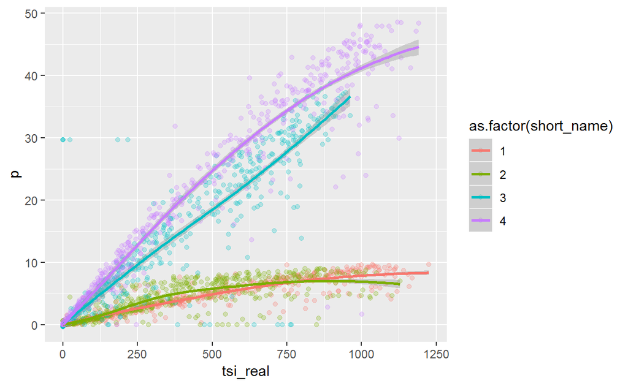

```r
train_data_1 %>%
    group_by(short_name) %>%
    sample_n(1000) %>%
    ggplot(aes(x = tsi_real,y = p,col=as.factor(short_name))) +
    geom_point(alpha=0.25) +
    geom_smooth(method = 'loess')
```

1. 四个电板分别不同需要区别对待。

### 假设二

> 但是有考虑过辐照度和温度之间的组合 光伏板受温度影响还是有一些的 温度高了发电效率就低了
1. 如下，显然温度和功率的相关性不大。

```r
eda_data_1 %>%
    summarise(
        cor=cor(p,temperature)
    ) %>%
    write_excel_csv(
        file.path(
            'data'
            ,paste(today() %>% str_remove_all('-') %>% str_sub(3,-1),'jiaxiang_edadata2.csv',sep='_')
        )
    )
```

```r
fread(file.path(
    'data'
    ,list.files('data') %>% str_subset('jiaxiang_edadata2.csv') %>% max
)
,encoding = 'UTF-8'
)
```

```
         cor
1: 0.1870181
```

### 假设三

> 两个方向:
> 1. 根据实发辐照度和实发功率建立回归模型
> 2. 根据预测辐照度和实发功率建立回归模型

test组没有实发辐照度，因此方向一的进行是

1. 通过其他x变量预测 test组 实发辐照度
2. 通过其他x变量和实发辐照度训练模型，最后预测 test组 实发功率

### 假设四

> 辐照度进行了归一化处理 范围为[-1, 1] -1表示辐照度为0（通常意义上的晚上）
> 1. 风速是评估风资源的，在光伏电站没什么用
> 2. 风向同上，但是可以看出主风向（北风是0、南风是180、东风是90）
> 3. 温度湿度体现不出什么东西
> 4. 实发功率晚上不发电（所以为0的基本上没有意义）

的确相关性也不是很高。

```r
eda_data_1 %>%
    summarise(
        cor_weedspeed=cor(p,weedspeed)
        ,cor_winddirection=cor(p,winddirection)
        ,cor_pressure=cor(p,pressure)
        ,cor_humidity=cor(p,humidity)
    ) %>%
    write_excel_csv(
        file.path(
            'data'
            ,paste(today() %>% str_remove_all('-') %>% str_sub(3,-1),'jiaxiang_edadata4.csv',sep='_')
        )
    )
```

```r
fread(file.path(
    'data'
    ,list.files('data') %>% str_subset('jiaxiang_edadata4.csv') %>% max
)
,encoding = 'UTF-8'
)
```

```
   cor_weedspeed cor_winddirection cor_pressure cor_humidity
1:   -0.05790542        0.05931748  -0.05066871   -0.2890449
```

## 最新讨论

> 直接用神经网络就行

搭建好keras的框架，进行训练。

`@`靳晓松 辐照度作为一个模型的预测，我觉得还是可以尝试一下，不好就不用好了。

`@`靳晓松 脏的地方，我觉得时间是不是可以聚合到同频率，这样可以用其他三个发电站的数据作为剩下一个的自变量来预测做模型。我还没看，等下试试。

「 靳晓松: 我发现了很多实发功率为0，实发辐照度为0，但是预测辐照度不为-1的样本 」 这个没明白，晓松举个实际数据的例子？

嗯，real_irradiance == 0 & irradiance != -1 & power < 0

这是筛选条件对么？那么我们是直接删除这些样本去训练，还是说，要修改value

## EDA by Trelliscope

Trelliscope 相关内容可参考 [Trelliscope 使用技巧](http://jiaxiangli.netlify.com/2018/10/trelliscope/) 。

```r
library(trelliscopejs)
library(tidyverse)
eda_data_1 %>%
    ungroup %>%
    rename(year = `year(t)`,quarter = `quarter(t)`) %>%
    mutate(t = as.numeric(t)) %>%
    # trelliscopejs 暂时不支持时间变量
    mutate_at(vars(short_name,year,quarter),as.factor) %>%
    ggplot(aes(t, p)) +
    geom_line() +
    facet_trelliscope(
                      ~ short_name+year+quarter
                      ,nrow = 3
                      ,ncol = 4
                      ,path = "trelliscope/p"
                      )

# tsi
library(trelliscopejs)
library(tidyverse)
eda_data_1 %>%
    ungroup %>%
    rename(year = `year(t)`,quarter = `quarter(t)`) %>%
    mutate(t = as.numeric(t)) %>%
    # trelliscopejs 暂时不支持时间变量
    mutate_at(vars(short_name,year,quarter),as.factor) %>%
    ggplot(aes(t, tsi)) +
    geom_line() +
    facet_trelliscope(
                      ~ short_name+year+quarter
                      ,nrow = 3
                      ,ncol = 4
                      ,path = "trelliscope/tsi"
                      )

# tsi_real
library(trelliscopejs)
library(tidyverse)
eda_data_1 %>%
    ungroup %>%
    rename(year = `year(t)`,quarter = `quarter(t)`) %>%
    mutate(t = as.numeric(t)) %>%
    # trelliscopejs 暂时不支持时间变量
    mutate_at(vars(short_name,year,quarter),as.factor) %>%
    ggplot(aes(t, tsi_real)) +
    geom_line() +
    facet_trelliscope(
                      ~ short_name+year+quarter
                      ,nrow = 3
                      ,ncol = 4
                      ,path = "trelliscope/tsi_real"
                      )
```

## 聚合指标

使用结构方程 具体参考 [因子分析 Factor Analysis](https://jiaxiangli.netlify.com/2018/10/factor-analysis/)

## 晓松的反馈

### `光伏短期功率预测-靳晓松-20181020.docx`

两步骤模型

$$\begin{cases}
\text{其他变量} \xrightarrow{预测} \text{实发辐照度} \\
\text{实发辐照度} \xrightarrow{预测} \text{实发功率} \\
\end{cases}$$

### `光伏短期功率预测-靳晓松-20181021.docx`

#### 实发功率

1. 硬件采集 -> 实发功率 -> 处理方法：直接剔除
2. 实发辐照度 -> 实发功率
- 系统性出现的是
  - 恒定值，我们标准化的时候可以处理掉
  - 异常值，我们用箱型图取上下限

#### predict辐照度

1. 地理坐标（根据大气物理方程） -> 预测辐照度（公司预测方法）
2. 预测辐照度 + 湿度 + 温度（阴雨天） -> 预测辐照度（我们的方法）
- 第二条没有太懂。

## arima模型

2.15 arima预测半年收益率 https://jiaxiangli.netlify.com/2018/06/phoenix-finance/ 27 ARIMA模型加入多个x变量 https://jiaxiangli.netlify.com/2018/04/training-model/

## 四个发电板实发辐照度相关性 {#4psi4}

```r
eda_data_1 %>%
    select(short_name,t,tsi_real) %>%
    mutate(t = as.Date(t)) %>%
    group_by(short_name,t) %>%
    summarise(tsi_real = mean(tsi_real)) %>%
    spread(short_name,tsi_real) %>%
    na.omit() %>%
    select(-t) %>%
    as.data.frame() %>%
    psych::corr.test(., use = "pairwise.complete.obs") %>%
    .$ci
```

```
        lower         r     upper            p
1-2 0.6234828 0.7133702 0.7846449 3.753184e-24
1-3 0.7528078 0.8153328 0.8632763 3.128120e-36
1-4 0.8264841 0.8717370 0.9057967 9.000866e-47
2-3 0.6163816 0.7076590 0.7801717 1.241295e-23
2-4 0.5667945 0.6674430 0.7484616 2.669775e-20
3-4 0.6843229 0.7618166 0.8222939 3.933517e-29
```

## 影响路径

结构方程查看 [因子分析 Factor Analysis](https://jiaxiangli.netlify.com/2018/10/factor-analysis/) 。

```r
library(lavaan)
sem_model <- '
tsi ~ weedspeed + winddirection + temperature + pressure + humidity
tsi_real ~ tsi + weedspeed + winddirection + temperature + pressure + humidity
p ~ tsi_real
'
```

1. 如果有其他路径，可以反馈一下。

```r
sem_fit <- cfa(sem_model,data=train_data_1)
```

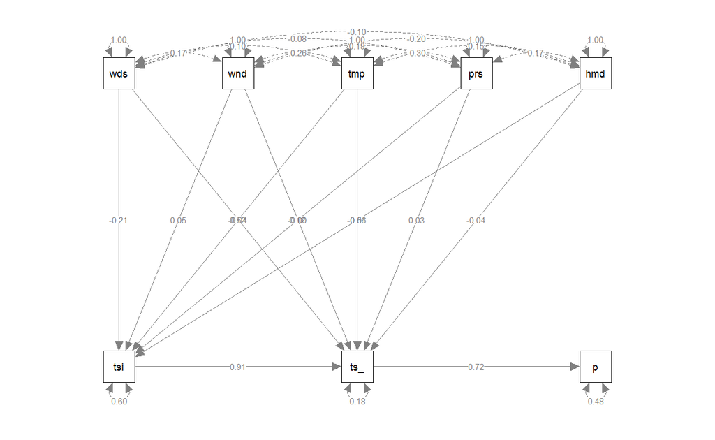

```r
library(semPlot)
semPaths(sem_fit,whatLabels = 'std')
```

```r
summary(sem_fit,fit.measures = T,standardized = T)
```

```
lavaan 0.6-2 ended normally after 120 iterations

  Optimization method                           NLMINB
  Number of free parameters                         15

  Number of observations                        183096

  Estimator                                         ML
  Model Fit Test Statistic                    1410.980
  Degrees of freedom                                 6
  P-value (Chi-square)                           0.000

Model test baseline model:

  Minimum Function Test Statistic           566794.313
  Degrees of freedom                                18
  P-value                                        0.000

User model versus baseline model:

  Comparative Fit Index (CFI)                    0.998
  Tucker-Lewis Index (TLI)                       0.993

Loglikelihood and Information Criteria:

  Loglikelihood user model (H0)             -1865977.853
  Loglikelihood unrestricted model (H1)     -1865272.363

  Number of free parameters                         15
  Akaike (AIC)                              3731985.706
  Bayesian (BIC)                            3732137.472
  Sample-size adjusted Bayesian (BIC)       3732089.801

Root Mean Square Error of Approximation:

  RMSEA                                          0.036
  90 Percent Confidence Interval          0.034  0.037
  P-value RMSEA <= 0.05                          1.000

Standardized Root Mean Square Residual:
```

[output cut: 37 more lines]

```
   -0.060
    0.034
   -0.041

    0.719

Variances:
                   Estimate   Std.Err  z-value  P(>|z|)   Std.lv
   .tsi                0.180    0.001  302.569    0.000     0.180
   .tsi_real       18204.816   60.167  302.569    0.000 18204.816
   .p                 43.567    0.144  302.569    0.000    43.567
  Std.all
    0.595
    0.177
    0.483
```

我验证了晓松的学长的思路。

1. 总体看，这么预测，通过两部预测`p ~ tsi_real`和`tsi_real ~ tsi + ...` 来预测是可行的。
2. 疑惑的是，`winddirection`和`pressure`这两个指标并不好，我估计是大气方程定义的，因此需要知道下需要做什么样的数据变换，如`log`等，大家有空找找看吗?

## 武神回复

2018年4月的数据应该也有问题，在这个时间点上，同样的实发功率，但是辐照度变化很大 我感觉可以观察每个面板，每个月，实发功率和实发辐照度的箱线图，箱体太大的应该是有问题。

```r
library(glue)
library(psych)
train_data_1 %>%
    mutate(year=year(t),month=month(t)) %>%
    select(short_name,year,month,p,tsi_real) %>%
    group_by(short_name,year,month) %>%
    nest() %>%
    mutate(data = map(data,describe)) %>%
    unnest() %>%
    filter(short_name == 2,vars==1)
```

```
# A tibble: 16 x 16
   short_name  year month  vars     n  mean    sd median trimmed   mad
        <int> <dbl> <dbl> <int> <dbl> <dbl> <dbl>  <dbl>   <dbl> <dbl>
 1          2  2017     1     1  2880  1.82  2.74  0       1.34  0
 2          2  2017     2     1  2687  1.82  2.72  0       1.39  0
 3          2  2017     3     1  2975  2.27  3.03  0       1.83  0
 4          2  2017     4     1  2878  2.23  2.88  0.167   1.78  0.247
 5          2  2017     5     1  2974  2.40  3.07  0.333   1.96  0.494
 6          2  2017     6     1  2349  1.69  2.59  0       1.16  0
 7          2  2017     7     1  2507  2.01  2.35  0.34    1.75  0.504
 8          2  2017     8     1  1677  1.88  2.21  0.227   1.67  0.336
 9          2  2017     9     1  2726  1.05  1.89  0       0.545 0
10          2  2017    10     1  2976  1.91  2.90  0       1.38  0
11          2  2017    11     1  2880  2.14  3.09  0       1.69  0
12          2  2017    12     1  2727  1.73  2.72  0       1.27  0
13          2  2018     1     1  2975  1.72  2.71  0       1.24  0
14          2  2018     2     1  2688  1.97  2.83  0       1.53  0
15          2  2018     3     1  2976  2.40  3.29  0       1.91  0
16          2  2018     4     1  2880  2.69  3.29  0.453   2.27  0.672
# ... with 6 more variables: min <dbl>, max <dbl>, range <dbl>,
#   skew <dbl>, kurtosis <dbl>, se <dbl>
```

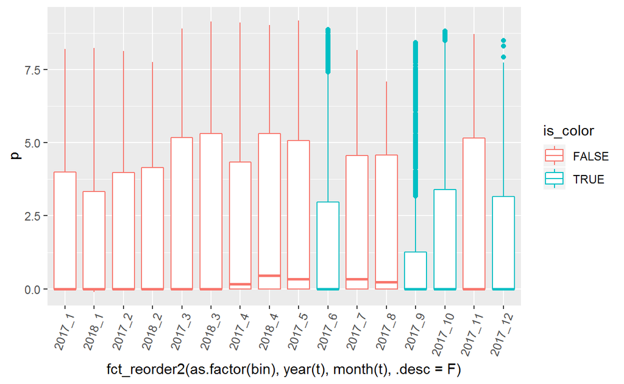

```r
train_data_1 %>%
    filter(short_name==2) %>%
    mutate(bin = glue('{year(t)}_{month(t)}')) %>%
    mutate(is_color = (year(t) == 2017 & month(t) %in% c(6,9,10,12))) %>%
    ggplot(aes(x=fct_reorder2(as.factor(bin),year(t),month(t),.desc = F),y=p,col=is_color)) +
    geom_boxplot() +
    theme(axis.text.x = element_text(angle = 70, hjust = 1))
```

1. 异常值多的，主要是绿色部分。
2. 表现为实际功率偏高。

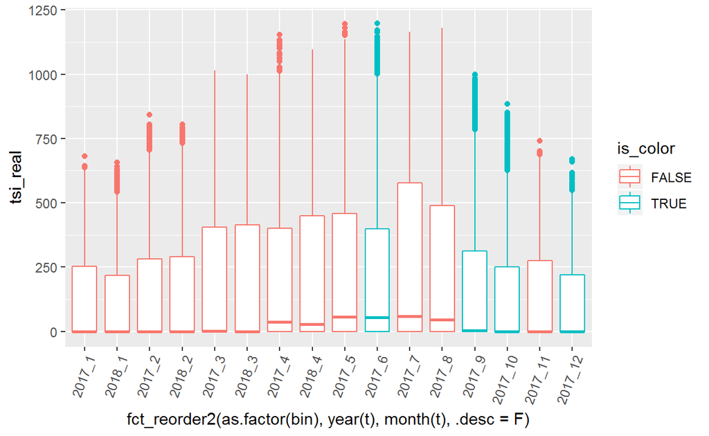

```r
train_data_1 %>%
    filter(short_name==2) %>%
    mutate(bin = glue('{year(t)}_{month(t)}')) %>%
    mutate(is_color = (year(t) == 2017 & month(t) %in% c(6,9,10,12))) %>%
    ggplot(aes(x=fct_reorder2(as.factor(bin),year(t),month(t),.desc = F),y=tsi_real,col=is_color)) +
    geom_boxplot() +
    theme(axis.text.x = element_text(angle = 70, hjust = 1))
```

1. 同时实发辐照度在这写月份也有很高的异常值。

或者用js看。

## 时间间隔为15 min {#15min}

[DC运营](http://www.dcjingsai.com/common/bbs/topicDetails.html?tid=2298) 回复。

```r
train_data_1 %>%
    group_by(minute(round_date(t,unit = 'minute'))) %>%
    count()
```

```
# A tibble: 4 x 2
# Groups:   minute(round_date(t, unit = "minute")) [4]
  `minute(round_date(t, unit = "minute"))`     n
                                     <int> <int>
1                                        0 45768
2                                       15 45774
3                                       30 45778
4                                       45 45776
```

## gamma分布一定有问题

```r
list.files('data',full.names = T) %>%
    str_subset('jiaxiang_prediction_') %>%
    data.table(name=.) %>%
    mutate(data = map(name,fread)) %>%
    unnest() %>%
    # group_by(name) %>%
    # summarise(n_distinct(predicition)) %>%
    # 都没有之前的重复值多，所以结果不好，那么我觉得是gamma函数的问题。
    spread(name,predicition) %>%
    set_names('id',c(1:5)) %>%
    select(-id) %>%
    psych::corr.test(use = "pairwise.complete.obs") %>%
    .$ci
    # 发现后面三个结果是一样的。
```

## yaml 备份

```
---
title: "短期光伏功率预测"
subtitle: "数据描述"
author: "李家翔"
date: "2018-11-05"
output:
  bookdown::html_document2:
    code_folding: hide
    df_print: kable
    highlight: textmate
    number_sections: yes
    theme: yeti
    toc: yes
    toc_float: yes
bibliography: ../../../blog_180802/content/post/add.bib
---
```